# MSc Thesis - Coral light acclimatization: illuminating the Montipora capitata proteome

Permentier

2024-06-14

# Libraries

```r
suppressPackageStartupMessages({
  library(readr)
  library(dplyr)
  library(arrow)
  library(tidyr)
  library(DEP)
  library(vegan)
  library(ggplot2)
  library(ComplexHeatmap)
  library(limma)
  library(tibble)
  library(clusterProfiler)
  library(enrichplot)
  library(pathview)
  library(ggrepel)
  library(Biostrings)
  library(KEGGREST)
  library(WGCNA)
  library(GO.db)
  library(topGO)
  library(ggVennDiagram)
  library(gridExtra)
  library(stringr)
})
```

```
##
## groupGOTerms:    GOBPTerm, GOMFTerm, GOCCTerm environments built.
```

# Sequence database

This is the FASTA used for searching M. capitata proteins.

```r
FASTA_Mcap <- readAAStringSet("C:/Users/trist/OneDrive - Vrije Universiteit Brussel/Desktop/Thesis/Proteomics/FASTA/Genome/Stephens/Montipora_capitata_HIv3.genes.pep.FASTA")
length(FASTA_Mcap)
```

```
## [1] 54384
```

```r
head(names(FASTA_Mcap))
```

```
## [1] "Montipora_capitata_HIv3___TS.g31918.t1"
## [2] "Montipora_capitata_HIv3___RNAseq.g39902.t1"
## [3] "Montipora_capitata_HIv3___RNAseq.g22918.t1"
## [4] "Montipora_capitata_HIv3___RNAseq.g7985.t1"
## [5] "Montipora_capitata_HIv3___RNAseq.g36632.t1"
## [6] "Montipora_capitata_HIv3___RNAseq.g20158.t1"
```

Symbionts.

```r
FASTA_symbiont <- readAAStringSet("C:/Users/trist/OneDrive - Vrije Universiteit Brussel/Desktop/Thesis/Proteomics/FASTA/Symbiodiniaceae/Reefgenomics clade C1/SymbC1.Gene_Models.PEP.FASTA")
length(FASTA_symbiont)
```

```
## [1] 35913
```

```r
head(names(FASTA_symbiont))
```

```
## [1] "SymbC1.scaffold1.2 SymbC1.scaffold1:4852-11901(-)"
## [2] "SymbC1.scaffold1.7 SymbC1.scaffold1:23771-24727(+)"
## [3] "SymbC1.scaffold1.10 SymbC1.scaffold1:26755-30359(+)"
## [4] "SymbC1.scaffold1.12 SymbC1.scaffold1:33231-35471(+)"
## [5] "SymbC1.scaffold1.22 SymbC1.scaffold1:55674-58238(-)"
## [6] "SymbC1.scaffold1.24 SymbC1.scaffold1:61471-67516(-)"
```

cRAP:

```r
FASTA_cRAP <- readAAStringSet("C:/DIA-NN/1.9/camprotR_240512_cRAP_20190401_full_tags.FASTA")
length(FASTA_cRAP)
```

```
## [1] 125
```

```r
head(names(FASTA_cRAP))
```

```
## [1] "sp|cRAP-P00330|cRAP-ADH1_YEAST Alcohol dehydrogenase 1 OS=Saccharomyces cerevisiae (strain ATCC 204508 / S288c) GN=cRAP-ADH1 PE=1 SV=5"
## [2] "sp|cRAP-P02768|cRAP-ALBU_HUMAN Serum albumin OS=Homo sapiens GN=cRAP-ALB PE=1 SV=2"
## [3] "sp|cRAP-P00883|cRAP-ALDOA_RABIT Fructose-bisphosphate aldolase A OS=Oryctolagus cuniculus GN=cRAP-ALDOA PE=1 SV=2"
## [4] "sp|cRAP-P04745|cRAP-AMY1_HUMAN Alpha-amylase 1 OS=Homo sapiens GN=cRAP-AMY1A PE=1 SV=2"
## [5] "sp|cRAP-P01008|cRAP-ANT3_HUMAN Antithrombin-III OS=Homo sapiens GN=cRAP-SERPINC1 PE=1 SV=1"
## [6] "sp|cRAP-P08758|cRAP-ANXA5_HUMAN Annexin A5 OS=Homo sapiens GN=cRAP-ANXA5 PE=1 SV=2"
```

Sequence database.

```r
FASTA_df <- rbind(tibble(FASTA_header = names(FASTA_Mcap),Sequence = as.character(FASTA_Mcap)) %>%
                    mutate(Organism = "Montipora capitata"),
                  tibble(FASTA_header = names(FASTA_symbiont),Sequence = as.character(FASTA_symbiont)) %>%
                    mutate(Organism = "Symbiodiniaceae"),
                  tibble(FASTA_header = names(FASTA_cRAP),Sequence = as.character(FASTA_cRAP)) %>%
                    mutate(Organism = "cRAP"))
```

# Experimental design

Experimental design table

```r
design <- read.csv("C:/Users/trist/OneDrive - Vrije Universiteit Brussel/Desktop/Thesis/Proteomics/Metadata/GoogleDrive_Emma/DIA_metadata.csv")
design <- design %>%
  mutate_all(as.factor) %>%
  mutate(Treatment = recode(Treatment, `C` = "Light", `S` = "Shade")) %>%
  filter(Method == "DIA")
```

Necessary for SummarizedExperiment: condition, label and replicate columns (lower caps).

```r
design <- design %>%
  group_by(Treatment) %>%
  dplyr::rename(condition = Treatment) %>%
  mutate(replicate = row_number(),
         label=paste(condition, replicate, sep = "_")) %>%
  ungroup() %>%
  dplyr::select(File.Name,Tag,Sample_ID,label,everything())
design
```

```
## # A tibble: 36 × 21
##    File.Name      Tag   Sample_ID label Path  Instrument.Method Position Inj.Vol
##    <fct>          <fct> <fct>     <chr> <fct> <fct>             <fct>    <fct>
##  1 20240424_UWPR… S1-8… S_19_1    Shad… "C:\… "C:\\Xcalibur\\d… A2       4
##  2 20240424_UWPR… S3-9… S_P1R2_3  Shad… "C:\… "C:\\Xcalibur\\d… A3       4
##  3 20240424_UWPR… S3-3… S_19_3    Shad… "C:\… "C:\\Xcalibur\\d… A4       4
##  4 20240424_UWPR… C2-3… C_P1R2_2  Ligh… "C:\… "C:\\Xcalibur\\d… A5       4
##  5 20240424_UWPR… C1-8… C_90_1    Ligh… "C:\… "C:\\Xcalibur\\d… A6       4
##  6 20240424_UWPR… C3-9… C_64Y_3   Ligh… "C:\… "C:\\Xcalibur\\d… A7       4
##  7 20240424_UWPR… S2-9… S_90_2    Shad… "C:\… "C:\\Xcalibur\\d… A8       4
##  8 20240424_UWPR… C3-2… C_64_3    Ligh… "C:\… "C:\\Xcalibur\\d… B2       4
##  9 20240424_UWPR… C1-2… C_64_1    Ligh… "C:\… "C:\\Xcalibur\\d… B3       4
## 10 20240424_UWPR… S1-7… S_64Y_1   Shad… "C:\… "C:\\Xcalibur\\d… B4       4
## # ℹ 26 more rows
## # ℹ 13 more variables: Comment <fct>, Method <fct>, Run.order <fct>, TIC <fct>,
## #   condition <fct>, Rack <fct>, Experiment <fct>, Genotype <fct>,
## #   Group.order <fct>, Plate.Row <fct>, Plate.Column <fct>,
## #   Sampled_twice <fct>, replicate <int>
```

# DIA-NN

Load the parquet data and exclude false discoveries: 600K precursor ion identifications/quantifications.

```r
dfp <- read_parquet("report.parquet")
```

For every identification in each file, match the file name to the label. label will form the connection between the assay data and the design data in the SummarizedExperiment.

```r
dfp <- dfp %>%
  dplyr::rename(File.Name = Run) %>%
  dplyr::left_join(design %>% dplyr::select(File.Name,label), by = "File.Name") %>%
  dplyr::select(label,File.Name,everything())
```

Get the protein measurements.

```r
dfp_proteins <- dfp %>%
  #Exclude false discoveries (FDR < 0.01%)
  filter(Global.PG.Q.Value <= 0.01) %>%
  # Transform precursor ion format to protein group format: retain protein groups with maximal LFQ value
  group_by(Protein.Group, label) %>%
  filter(PG.MaxLFQ.Quality == max(PG.MaxLFQ.Quality, na.rm = TRUE)) %>%
  dplyr::slice(1)  # In case of ties, take the first one
dim(dfp_proteins)[1]
```

```
## [1] 204028
```

Wide format protein Abundance data: 8378 protein groups.

```r
prot <- dfp_proteins %>%
  dplyr::select(c("Protein.Group","Genes","PG.Normalised","label")) %>%
  pivot_wider(names_from = label, values_from = PG.Normalised)
dim(prot)
```

```
## [1] 8378   38
```

Match organism information to protein groups.

```r
prot_organism <- prot %>%
  mutate(Protein_Group = Protein.Group) %>%
  separate_rows(Protein.Group,sep=";") %>%
  dplyr::select(Protein_Group,Protein.Group) %>%
  dplyr::rename(Protein = Protein.Group) %>%
  mutate(Organism = ifelse(grepl("Montipora_capitata",Protein),"Montipora capitata",
                           ifelse(grepl("cRAP",Protein),"cRAP",
                                  ifelse(grepl("Symb",Protein),"Symbiodiniaceae","Code failure")))) %>%
  group_by(Protein_Group) %>%
  summarize(Organism_list = paste(unique(Organism), collapse = ";")) %>%
  mutate(Organism = ifelse(grepl(";",Organism_list),"uncertain",Organism_list)) %>%
  dplyr::select(Protein_Group,Organism) %>%
  dplyr::rename(Protein.Group = Protein_Group) %>%
  mutate(Organism = as.factor(Organism)) %>%
  distinct()
unique(prot_organism$Organism)
```

```
## [1] Montipora capitata Symbiodiniaceae    cRAP
## Levels: cRAP Montipora capitata Symbiodiniaceae
```

Add organism information to protein dataset.

```r
prot <- prot %>%
  left_join(prot_organism,by="Protein.Group") %>%
  dplyr::select(Organism,everything())
dim(prot)
```

```
## [1] 8378   39
```

Long format protein abundance data.

```r
prot_long <- prot %>%
  pivot_longer(
    cols = matches("^(Light_|Shade_)"),
    names_to = "label",
    values_to = "PG.Normalised"
  ) %>%
  left_join(design,by="label")
dim(prot_long)
```

```
## [1] 301608     25
```

# Generate SummarizedExperiment object

Input protein data.

```r
protein_data <- prot %>%
  filter(Organism !="cRAP")
dim(prot)[1]
```

```
## [1] 8378
```

```r
dim(protein_data)[1]
```

```
## [1] 8360
```

Proteins must get a name and ID column using make_unique.

```r
data_unique <- make_unique(protein_data,"Protein.Group","Genes")
data_unique <- data_unique %>%
  dplyr::select(name,ID,everything())
dim(data_unique)[1]
```

```
## [1] 8360
```

Are there any duplicated names?

```r
data_unique$name %>% duplicated() %>% any()
```

```
## [1] FALSE
```

Next we need an integer vector with column numbers indicating the label names of the columns containing the assay data.

```r
columns <- grep("_",colnames(data_unique))
colnames(data_unique)[columns]
```

```
##  [1] "Light_1"  "Light_10" "Light_11" "Light_12" "Light_13" "Light_14"
##  [7] "Light_15" "Light_16" "Light_17" "Light_18" "Light_2"  "Light_3"
## [13] "Light_4"  "Light_5"  "Light_6"  "Light_7"  "Light_8"  "Light_9"
## [19] "Shade_1"  "Shade_10" "Shade_11" "Shade_12" "Shade_13" "Shade_14"
## [25] "Shade_15" "Shade_16" "Shade_17" "Shade_18" "Shade_2"  "Shade_3"
## [31] "Shade_4"  "Shade_5"  "Shade_6"  "Shade_7"  "Shade_8"  "Shade_9"
```

```r
data_se <- make_se(data_unique,columns,design)
```

# Data inspection

Number of protein groups per organism.

```r
prot_organism_count <- prot %>%
  group_by(Organism) %>%
  summarize(Total=n())
prot_organism_count
```

```
## # A tibble: 3 × 2
##   Organism           Total
##   <fct>              <int>
## 1 cRAP                  18
## 2 Montipora capitata  6613
## 3 Symbiodiniaceae     1747
```

Venn diagrams.

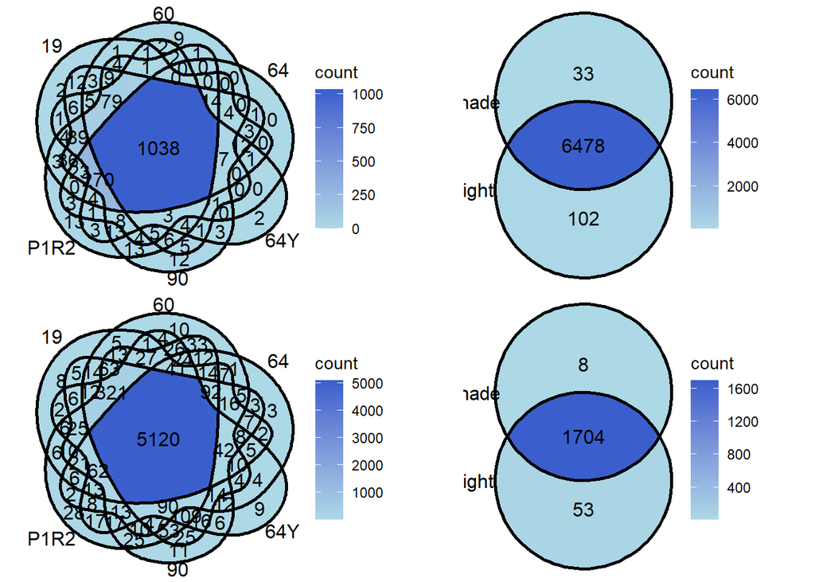

```r
Mcap_sets_condition <- prot_long %>%
  filter(!is.na(PG.Normalised),Organism=="Montipora capitata") %>%
  group_by(condition) %>%
  summarize(proteins = list(unique(Protein.Group))) %>%
  ungroup() %>%
  deframe()

venn_Mcap_condition <- ggVennDiagram(Mcap_sets_condition, label = "count",label_alpha = 0) +
  scale_fill_gradient(low = "lightblue", high = "royalblue3")

Mcap_sets_Genotype <- prot_long %>%
  filter(!is.na(PG.Normalised),Organism=="Symbiodiniaceae") %>%
  group_by(Genotype) %>%
  summarize(proteins = list(unique(Protein.Group))) %>%
  ungroup() %>%
  deframe()

venn_Mcap_Genotype <- ggVennDiagram(Mcap_sets_Genotype, label = "count",label_alpha = 0) +
  scale_fill_gradient(low = "lightblue", high = "royalblue3")

symb_sets_condition <- prot_long %>%
  filter(!is.na(PG.Normalised),Organism != "Montipora capitata") %>%
  group_by(condition) %>%
  summarize(proteins = list(unique(Protein.Group))) %>%
  ungroup() %>%
  deframe()

venn_symb_condition <- ggVennDiagram(symb_sets_condition, label = "count",label_alpha = 0) +
  scale_fill_gradient(low = "lightblue", high = "royalblue3")

symb_sets_Genotype <- prot_long %>%
  filter(!is.na(PG.Normalised),Organism != "Symbiodiniaceae") %>%
  group_by(Genotype) %>%
  summarize(proteins = list(unique(Protein.Group))) %>%
  ungroup() %>%
  deframe()

venn_symb_Genotype <- ggVennDiagram(symb_sets_Genotype, label = "count",label_alpha = 0) +
  scale_fill_gradient(low = "lightblue", high = "royalblue3")
grid.arrange(venn_Mcap_Genotype, venn_Mcap_condition, venn_symb_Genotype, venn_symb_condition, nrow = 2, ncol = 2)
```

Number of protein groups per organism per sample.

```r
prot_organism_sample_count <- prot_long %>%
  filter(!is.na(PG.Normalised)) %>%
  group_by(Sample_ID,Organism) %>%
  summarize(ProteinCount = sum(!is.na(PG.Normalised)))
```

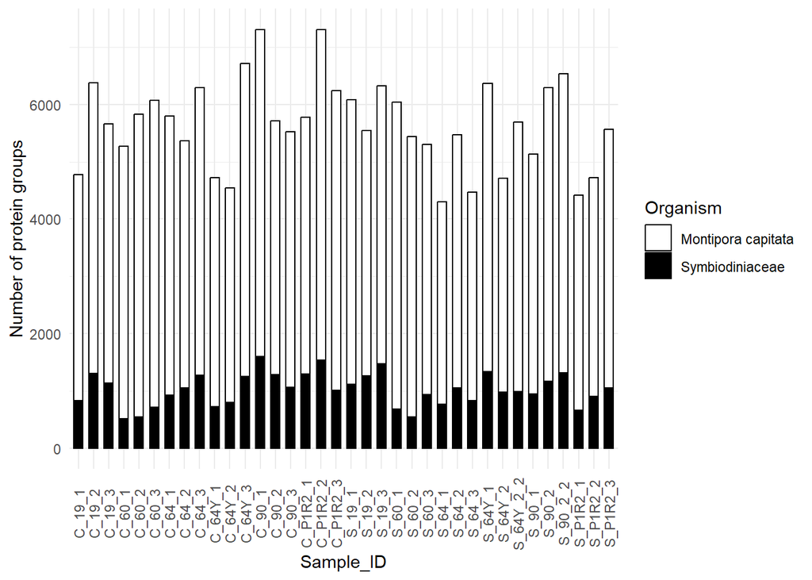

```r
composition <- ggplot(prot_organism_sample_count %>%
                        filter(Organism != "cRAP"),
                      aes(x=Sample_ID,y=ProteinCount,fill=Organism)) +
  geom_bar(
    stat = "identity",
    position = "stack",
    width=0.6,
    color="black") +
  theme(axis.text.x = element_text(angle = 90, hjust = 1, vjust = 0.5)) +
  scale_fill_manual(values = c("Montipora capitata" = "white",
                               "Symbiodiniaceae" = "black")) +
  theme_minimal() +
  labs(y = "Number of protein groups") +
  theme(axis.text.x = element_text(angle = 90, hjust = 0.5, vjust = 0.5))
composition
```

Signal intensity distribution per sample.

```r
prot_organism_sample_percentage <- prot_long %>%
  filter(!is.na(PG.Normalised)) %>%
  group_by(Sample_ID,Organism) %>%
  summarize(Itensity_sum = sum(log2(PG.Normalised))) %>%
  group_by(Sample_ID) %>%
  mutate(Total = sum(Itensity_sum),
         Percentage = (Itensity_sum / Total) * 100) %>%
  ungroup()
```

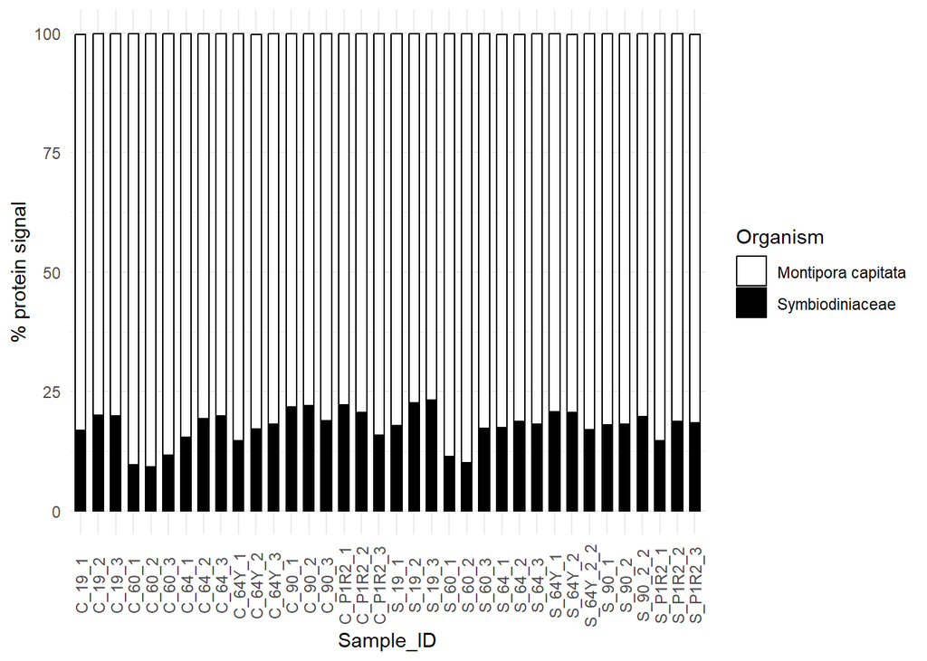

```r
composition <- ggplot(prot_organism_sample_percentage %>%
                        filter(Organism != "cRAP"),
                      aes(x=Sample_ID,y=Percentage,fill=Organism)) +
  geom_bar(
    stat = "identity",
    position = "stack",
    width=0.6,
    color="black") +
  theme(axis.text.x = element_text(angle = 90, hjust = 1, vjust = 0.5)) +
  scale_fill_manual(values = c("Montipora capitata" = "white",
                               "Symbiodiniaceae" = "black")) +
  theme_minimal() +
  labs(y = "% protein signal") +
  theme(axis.text.x = element_text(angle = 90, hjust = 0.5, vjust = 0.5))
composition
```

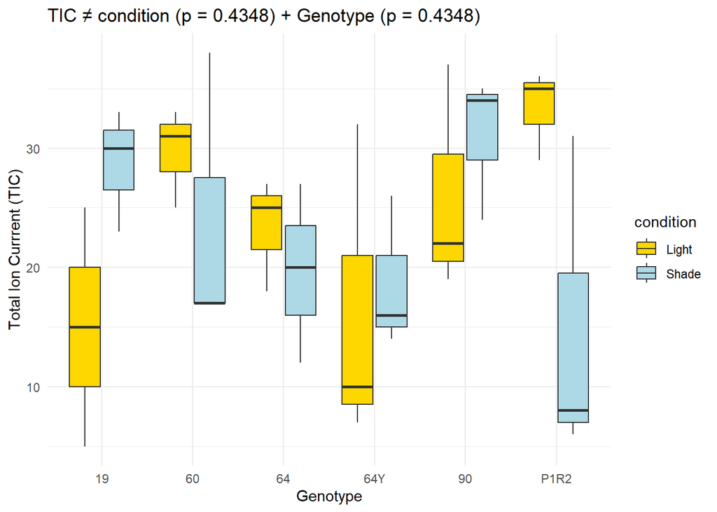

```r
anova_result <- aov(TIC ~ Genotype + condition, data = design %>%
                      filter(Method == "DIA") %>%
                      mutate(TIC = as.numeric(TIC)))
anova_summary <- summary(anova_result)
ggplot(design %>%
         filter(Method == "DIA") %>%
         mutate(TIC = as.numeric(TIC)), aes(x = Genotype, y = TIC, fill = condition)) +
  geom_boxplot() +
  theme_minimal() +
  scale_fill_manual(values = c("Light" = "gold", "Shade" = "lightblue")) +
  labs(x = "Genotype",
       y = "Total Ion Currrent (TIC)",
       title = sprintf("TIC ≠ condition (p = %.4f) + Genotype (p = %.4f)",
                       anova_summary[[1]]$`Pr(>F)`[1],
                       anova_summary[[1]]$`Pr(>F)`[1]))
```

```r
prot_long <- prot_long %>%
  left_join(data_unique %>% dplyr::select(name,Protein.Group),by="Protein.Group") %>%
  mutate(Log2Intensity=log2(PG.Normalised))
```

All proteins are good proteins (i.e. don’t need to be filtered out).

```r
prot_wide <- data.frame(SummarizedExperiment::assay(data_se))
colnames(prot_wide) <- SummarizedExperiment::colData(data_se)$Sample_ID
prot_wide <- prot_wide %>%
  rownames_to_column(var="name") %>%
  left_join(data_unique %>% dplyr::select(name,ID,Protein.Group,Organism,Genes),by="name") %>%
  dplyr::select(name,ID,Protein.Group,Organism,Genes,everything())

Abundances <- prot_wide %>%
  dplyr::select(-c(ID,Protein.Group,Organism,Genes)) %>%
  column_to_rownames(var="name") %>%
  mutate_all(~replace(., is.na(.), 0)) %>%
  t()

gsg = goodSamplesGenes(Abundances, verbose=3);
```

```
##  Flagging genes and samples with too many missing values...
##   ..step 1
```

```r
gsg$allOK
```

```
## [1] TRUE
```

Overlap between samples

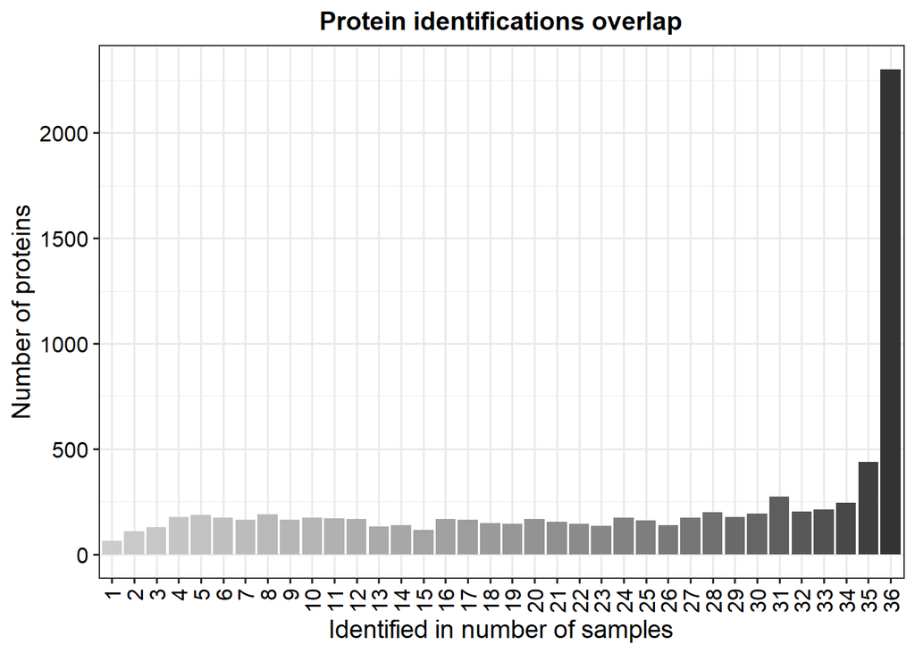

```r
# Plot a barplot of the protein identification overlap between samples
prot_freq_plot <- plot_frequency(data_se)
prot_freq_plot
```

Overlap between samples (coverage plot).

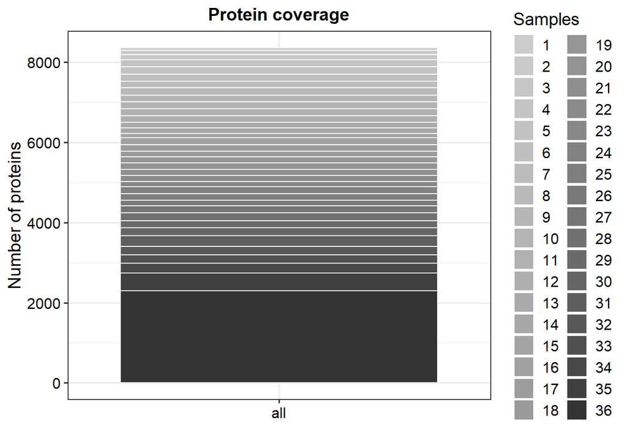

```r
# Plot a barplot of the protein identification overlap between samples
coverage_plot <- plot_coverage(data_se)
coverage_plot
```

Data normalization.DIANN does this, so this is just for illustration purposes.

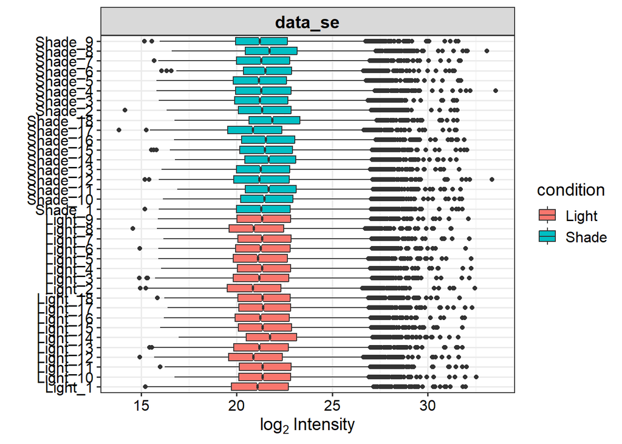

```r
norm_plot <- plot_normalization(data_se)
norm_plot
```

Proteins with missing values have on average low intensities: below the detection limit.

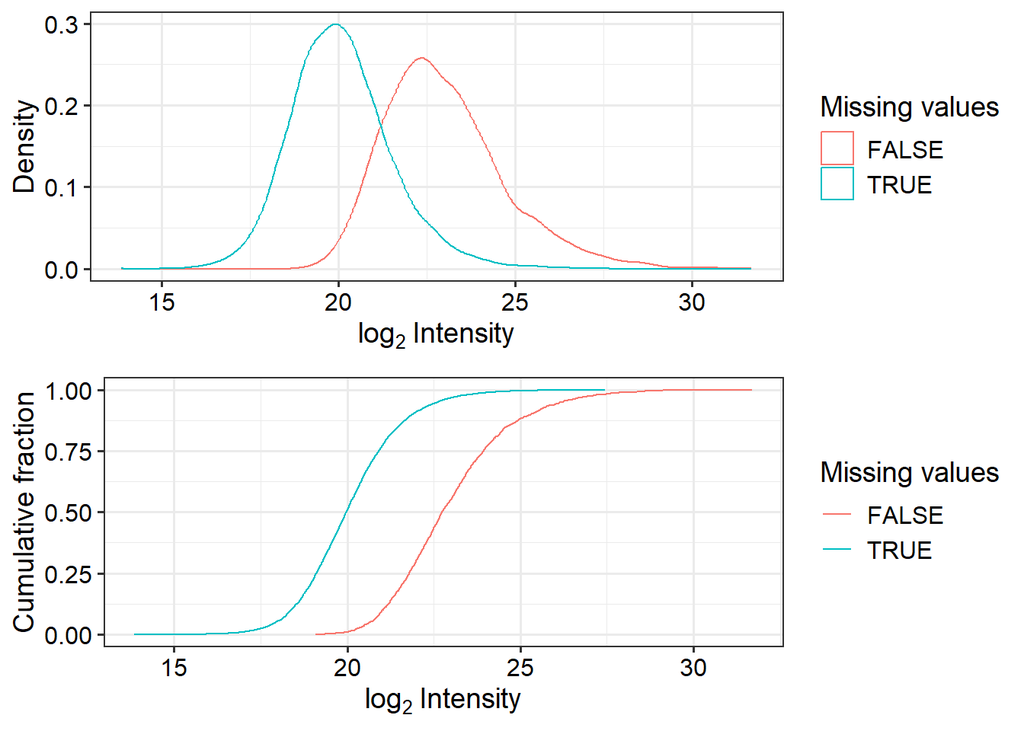

```r
missing_density_plot <- plot_detect(data_se)
```

```r
missing_density_plot
```

# Practical reformatting of the data

Wide format.

```r
prot_wide <- data.frame(SummarizedExperiment::assay(data_se))
colnames(prot_wide) <- SummarizedExperiment::colData(data_se)$Sample_ID
prot_wide <- prot_wide %>%
  rownames_to_column(var="name") %>%
  left_join(data_unique %>% dplyr::select(name,ID,Protein.Group,Organism,Genes),by="name") %>%
  dplyr::select(name,ID,Protein.Group,Organism,Genes,everything())
```

Number of protein groups.

```r
dim(prot_wide)[1]
```

```
## [1] 8360
```

# Ordination and multivariate testing Montipora capitata

Select Montipora capitata.

```r
Mcap_ordination_data <- prot_wide %>%
  filter(Organism == "Montipora capitata")
dim(Mcap_ordination_data)
```

```
## [1] 6613   41
```

Format protein data for vegan.

```r
Abundances <- Mcap_ordination_data %>%
  filter(Organism == "Montipora capitata") %>%
  dplyr::select(-c(ID,Protein.Group,Organism,Genes)) %>%
  column_to_rownames(var="name") %>%
  mutate_all(~replace(., is.na(.), 0)) %>%
  t()
```

NMDS.

```r
# NMDS
set.seed(123)
nmds <- metaMDS(Abundances, distance = "bray", k = 2)
```

```
## Wisconsin double standardization
## *** Best solution repeated 4 times
```

```r
nmds_points <- as.data.frame(nmds$points)
nmds_points <- tibble::rownames_to_column(nmds_points,var="Sample_ID")
nmds_metadata <- nmds_points %>%
  left_join(design %>% dplyr::select("condition","Genotype","Sample_ID","label","Sampled_twice","Plate.Row","Plate.Column"),by="Sample_ID")
nmds_stress <- nmds$stress
```

Bray Curtis distances.

```r
dist_matrix <- vegdist(Abundances, method = "bray")
```

I’m not detecting a batch effect.

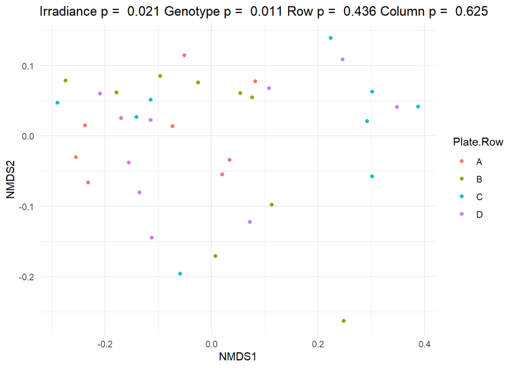

```r
permanova_result_batch <- adonis2(dist_matrix ~ condition + Genotype + Plate.Row + Plate.Column, data = nmds_metadata)
batch_plot <- ggplot(nmds_metadata, aes(x = MDS1, y = MDS2)) +
  geom_point(aes(color = Plate.Row)) +
  theme_minimal() +
  labs(title = paste("Irradiance p = ",format(permanova_result_batch$`Pr(>F)`[1], digits=3),
                     "Genotype p = ",format(permanova_result_batch$`Pr(>F)`[2], digits=3),
                     "Row p = ",format(permanova_result_batch$`Pr(>F)`[3], digits=3),
                     "Column p = ",format(permanova_result_batch$`Pr(>F)`[4], digits=3)), x = "NMDS1", y = "NMDS2")
batch_plot
```

PERMANOVA using Bray-Curtis distance four our question.

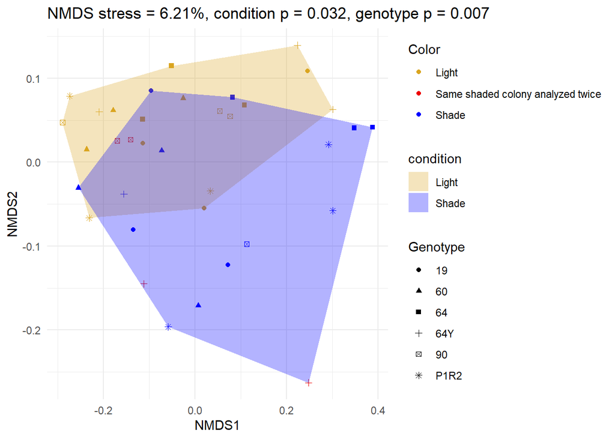

```r
permanova_result <- adonis2(dist_matrix ~ condition + Genotype, data = nmds_metadata)
p_value_condition <- permanova_result$`Pr(>F)`[1]
p_value_Genotype <- permanova_result$`Pr(>F)`[2]

hull.Light <- nmds_metadata[nmds_metadata$condition == "Light", ][chull(nmds_metadata[nmds_metadata$condition ==
    "Light", c("MDS1", "MDS2")]), ]  # hull values for control
hull.Shade <- nmds_metadata[nmds_metadata$condition == "Shade", ][chull(nmds_metadata[nmds_metadata$condition ==
    "Shade", c("MDS1", "MDS2")]), ]  # hull values for shade

hulls_condition <- rbind(hull.Light, hull.Shade)  #combine hulls

# Convert Sampled_twice to logical if it's not already
nmds_metadata$Color <- ifelse(as.logical(nmds_metadata$Sampled_twice), "Same shaded colony analyzed twice", as.character(nmds_metadata$condition))
# Plot
NMDS_plot <- ggplot(nmds_metadata, aes(x = MDS1, y = MDS2)) +
  geom_point(aes(color = Color, shape = Genotype)) +
  geom_polygon(data=hulls_condition,aes(x=MDS1,y=MDS2,fill=condition,group=condition),alpha=0.30)  +
  scale_fill_manual(values = c("Light" = "goldenrod", "Shade" = "blue")) +
  scale_color_manual(values = c("Light" = "goldenrod", "Shade" = "blue", "Same shaded colony analyzed twice" = "red2")) +
  theme_minimal() +
  labs(title = paste("NMDS stress = ", round(nmds_stress * 100, 2),
                     "%, condition p = ", format(p_value_condition, digits=3),
                     ", genotype p = ", format(p_value_Genotype, digits=3),sep=''),
       x = "NMDS1",
       y = "NMDS2")

NMDS_plot
```

# Ordination and multivariate testing symbionts

Select symbionts.

```r
symbiont_ordination_data <- prot_wide %>%
  filter(Organism != "Montipora capitata")
dim(symbiont_ordination_data)
```

```
## [1] 1747   41
```

Format protein data for vegan.

```r
Abundances <- symbiont_ordination_data %>%
  dplyr::select(-c(ID,Protein.Group,Organism,Genes)) %>%
  column_to_rownames(var="name") %>%
  mutate_all(~replace(., is.na(.), 0)) %>%
  t()
```

NMDS.

```r
# NMDS
set.seed(123)
nmds <- metaMDS(Abundances, distance = "bray", k = 2)
```

```
## Wisconsin double standardization
## *** Best solution repeated 4 times
```

```r
nmds_points <- as.data.frame(nmds$points)
nmds_points <- tibble::rownames_to_column(nmds_points,var="Sample_ID")
nmds_metadata <- nmds_points %>%
  left_join(design %>% dplyr::select("condition","Genotype","Sample_ID","label","Sampled_twice","Plate.Row","Plate.Column"),by="Sample_ID")
```

NMDS stress.

```r
nmds$stress
```

```
## [1] 0.04580132
```

I’m not detecting a batch effect.

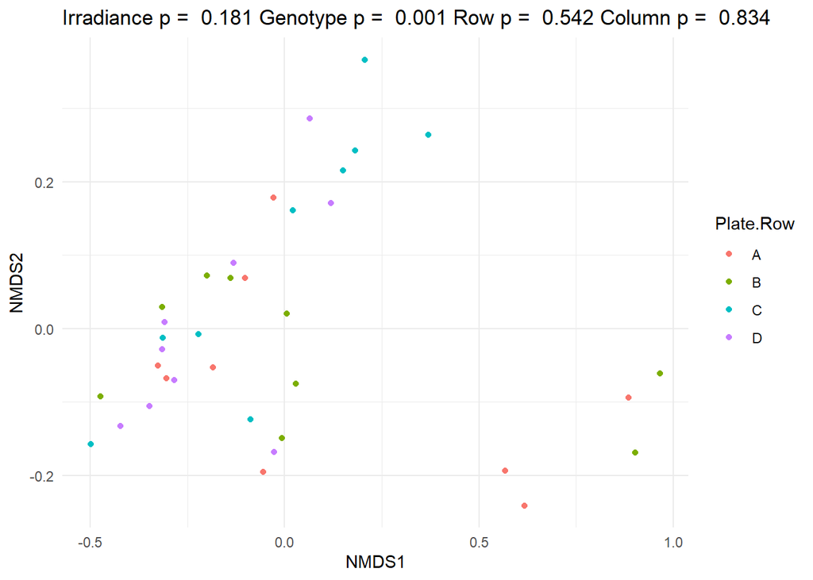

```r
dist_matrix <- vegdist(Abundances, method = "bray") # Bray Curtis distances
permanova_result_batch <- adonis2(dist_matrix ~ condition + Genotype + Plate.Row + Plate.Column, data = nmds_metadata)
batch_plot <- ggplot(nmds_metadata, aes(x = MDS1, y = MDS2)) +
  geom_point(aes(color = Plate.Row)) +
  theme_minimal() +
  labs(title = paste("Irradiance p = ",format(permanova_result_batch$`Pr(>F)`[1], digits=3),
                     "Genotype p = ",format(permanova_result_batch$`Pr(>F)`[2], digits=3),
                     "Row p = ",format(permanova_result_batch$`Pr(>F)`[3], digits=3),
                     "Column p = ",format(permanova_result_batch$`Pr(>F)`[4], digits=3)), x = "NMDS1", y = "NMDS2")
batch_plot
```

5 weird abnormal samples belonging to Genotype 6O (the only D-dominated genotype under analysis according to ITS2 sequencing).

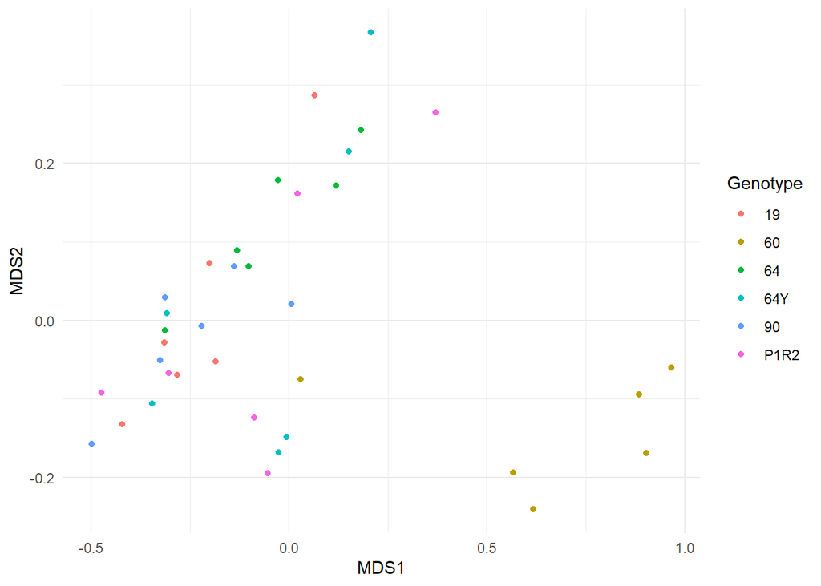

```r
Genotype_60_plot <- ggplot(nmds_metadata, aes(x = MDS1, y = MDS2)) +
  geom_point(aes(color = Genotype)) +
  theme_minimal()
Genotype_60_plot
```

Filter out genotype 60.

```r
Abundances <- rownames_to_column(data.frame(Abundances),var = "Sample_ID") %>%
  left_join(design %>% dplyr::select(Sample_ID,Genotype),by="Sample_ID") %>%
  filter(Genotype != "60") %>%
  dplyr::select(-Genotype) %>%
  column_to_rownames(var="Sample_ID") %>%
  as.matrix()
```

NMDS.

```r
# NMDS
set.seed(123)
nmds <- metaMDS(Abundances, distance = "bray", k = 2)
```

```
## Wisconsin double standardization
## *** Best solution repeated 7 times
```

```r
nmds_points <- as.data.frame(nmds$points)
nmds_points <- tibble::rownames_to_column(nmds_points,var="Sample_ID")
nmds_metadata <- nmds_points %>%
  left_join(design %>% dplyr::select("condition","Genotype","Sample_ID","label","Sampled_twice","Plate.Row","Plate.Column"),by="Sample_ID")
```

PERMANOVA using Bray-Curtis distance four our question.

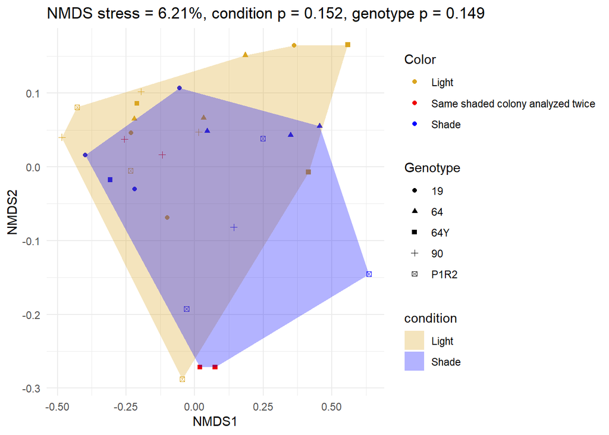

```r
dist_matrix <- vegdist(Abundances, method = "bray") # Bray Curtis distances
permanova_result <- adonis2(dist_matrix ~ condition + Genotype, data = nmds_metadata)
p_value_condition <- permanova_result$`Pr(>F)`[1]
p_value_Genotype <- permanova_result$`Pr(>F)`[2]

hull.Light <- nmds_metadata[nmds_metadata$condition == "Light", ][chull(nmds_metadata[nmds_metadata$condition ==
    "Light", c("MDS1", "MDS2")]), ]  # hull values for control
hull.Shade <- nmds_metadata[nmds_metadata$condition == "Shade", ][chull(nmds_metadata[nmds_metadata$condition ==
    "Shade", c("MDS1", "MDS2")]), ]  # hull values for shade

hulls_condition <- rbind(hull.Light, hull.Shade)  #combine hulls

# Convert Sampled_twice to logical if it's not already
nmds_metadata$Color <- ifelse(as.logical(nmds_metadata$Sampled_twice), "Same shaded colony analyzed twice", as.character(nmds_metadata$condition))
# Plot
NMDS_plot <- ggplot(nmds_metadata, aes(x = MDS1, y = MDS2)) +
  geom_point(aes(color = Color, shape = Genotype)) +
  geom_polygon(data=hulls_condition,aes(x=MDS1,y=MDS2,fill=condition,group=condition),alpha=0.30)  +
  scale_fill_manual(values = c("Light" = "goldenrod", "Shade" = "blue")) +
  scale_color_manual(values = c("Light" = "goldenrod", "Shade" = "blue", "Same shaded colony analyzed twice" = "red2")) +
  theme_minimal() +
  labs(title = paste("NMDS stress = ", round(nmds_stress * 100, 2),
                     "%, condition p = ", format(p_value_condition, digits=3),
                     ", genotype p = ", format(p_value_Genotype, digits=3),sep=''),
       x = "NMDS1",
       y = "NMDS2")

NMDS_plot
```

# Differential Abundance analysis

Model, taking into account Genotype as a fixed factor.

```r
model_design <- model.matrix(~ condition + Genotype, data = SummarizedExperiment::colData(data_se))
colnames(model_design)[colnames(model_design) == "(Intercept)"] <- "Intercept"
fit <- lmFit(SummarizedExperiment::assay(data_se), model_design)
contrast.matrix <- makeContrasts(conditionShade, levels = model_design)
fit <- contrasts.fit(fit, contrast.matrix)
fit <- eBayes(fit)
```

Differentially abundant proteins.

```r
prot_DAP <- topTable(fit, adjust.method = "BH", number = Inf) %>%
  dplyr::rename(log2FC = logFC) %>%
  mutate(log2FC = -log2(10^log2FC)) %>%
  mutate(Abundance = ifelse(adj.P.Val < 0.05 & abs(log2FC) > 1.5,ifelse(log2FC > 1.5,"up","down"),"no difference")) %>%
  rownames_to_column(var="name") %>%
  left_join(data_unique %>% dplyr::select(Organism,Protein.Group,name),by="name") %>%
  dplyr::select(Organism,name,Protein.Group,everything())
```

# Differences in Montipora capitata

CD-Search. Contains multiple entries for the same query.

```r
Mcap_CD <- read.csv("C:/Users/trist/OneDrive - Vrije Universiteit Brussel/Desktop/Thesis/Proteomics/FASTA/Genome/Stephens/Montipora_capitata_HIv3.genes.Conserved_Domain_Search_results.txt",sep="\t")
colnames(Mcap_CD)
```

```
##  [1] "Query"       "Hit.type"    "PSSM.ID"     "From"        "To"
##  [6] "E.Value"     "Bitscore"    "Accession"   "Short.name"  "Incomplete"
## [11] "Superfamily" "Definition"
```

```r
dim(Mcap_CD)[1]
```

```
## [1] 28406
```

```r
length(unique(Mcap_CD$Query))
```

```
## [1] 15838
```

EggNog.

```r
Mcap_egg <- read.csv("C:/Users/trist/OneDrive - Vrije Universiteit Brussel/Desktop/Thesis/Proteomics/FASTA/Genome/Stephens/Montipora_capitata_HIv3.genes.EggNog_results.txt",sep="\t")
colnames(Mcap_egg)
```

```
##  [1] "Query"          "seed_ortholog"  "evalue"         "score"
##  [5] "eggNOG_OGs"     "max_annot_lvl"  "COG_category"   "Description"
##  [9] "Preferred_name" "GOs"            "EC"             "KEGG_ko"
## [13] "KEGG_Pathway"   "KEGG_Module"    "KEGG_Reaction"  "KEGG_rclass"
## [17] "BRITE"          "KEGG_TC"        "CAZy"           "BiGG_Reaction"
## [21] "PFAMs"
```

```r
dim(Mcap_egg)[1]
```

```
## [1] 24072
```

KEGG.

```r
Mcap_KEGG <- read.csv("C:/Users/trist/OneDrive - Vrije Universiteit Brussel/Desktop/Thesis/Proteomics/FASTA/Genome/Stephens/Montipora_capitata_HIv3.genes.KEGG_results.txt",sep="\t")
colnames(Mcap_KEGG)
```

```
## [1] "Query" "KO"
```

```r
dim(Mcap_KEGG)[1]
```

```
## [1] 54384
```

Bind egg and KEGG together.

```r
Mcap_bio <- Mcap_KEGG %>%
  left_join(Mcap_egg,by="Query")
colnames(Mcap_bio)
```

```
##  [1] "Query"          "KO"             "seed_ortholog"  "evalue"
##  [5] "score"          "eggNOG_OGs"     "max_annot_lvl"  "COG_category"
##  [9] "Description"    "Preferred_name" "GOs"            "EC"
## [13] "KEGG_ko"        "KEGG_Pathway"   "KEGG_Module"    "KEGG_Reaction"
## [17] "KEGG_rclass"    "BRITE"          "KEGG_TC"        "CAZy"
## [21] "BiGG_Reaction"  "PFAMs"
```

```r
length(FASTA_Mcap)
```

```
## [1] 54384
```

```r
dim(Mcap_bio)[1]
```

```
## [1] 54384
```

Add data to differential abundance data.

```r
Mcap_DAP <- prot_DAP %>%
  filter(Organism == "Montipora capitata") %>%
  left_join(Mcap_bio %>% dplyr::rename(name=Query),by="name")
colnames(Mcap_DAP)
```

```
##  [1] "Organism"       "name"           "Protein.Group"  "log2FC"
##  [5] "AveExpr"        "t"              "P.Value"        "adj.P.Val"
##  [9] "B"              "Abundance"      "KO"             "seed_ortholog"
## [13] "evalue"         "score"          "eggNOG_OGs"     "max_annot_lvl"
## [17] "COG_category"   "Description"    "Preferred_name" "GOs"
## [21] "EC"             "KEGG_ko"        "KEGG_Pathway"   "KEGG_Module"
## [25] "KEGG_Reaction"  "KEGG_rclass"    "BRITE"          "KEGG_TC"
## [29] "CAZy"           "BiGG_Reaction"  "PFAMs"
```

```r
dim(Mcap_DAP)[1]
```

```
## [1] 6613
```

Heatmap.

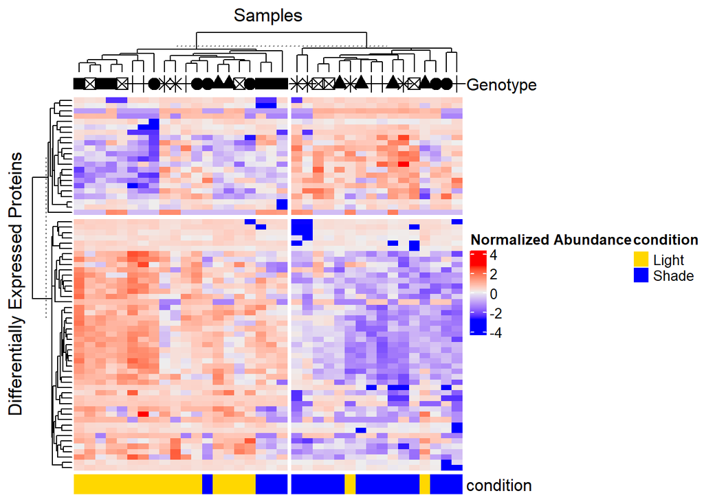

```r
Abundance_DAP <- prot_wide %>%
  filter(Organism == "Montipora capitata") %>%
  dplyr::select(-c(Organism,ID,Protein.Group,Genes)) %>%
  left_join(prot_DAP %>% dplyr::select(name,Abundance),by="name") %>%
  filter(Abundance != "no difference") %>%
  dplyr::select(-c(Abundance)) %>%
  column_to_rownames(var="name") %>%
  mutate_all(~replace(., is.na(.), 0)) %>%
  as.matrix()
# Z-score normalization for better visualization
Abundance_DAP_normalized <- t(scale(t(Abundance_DAP)))

# Create annotation data
column_annotations <- design[match(colnames(Abundance_DAP_normalized), design$Sample_ID), c("Genotype", "condition")]
genotype_symbols <- c("19" = 19, "60" = 17, "64" = 15, "64Y" = 3, "90" = 7, "P1R2" = 8)
ha_genotype <- columnAnnotation(
  Genotype = anno_simple(column_annotations$Genotype, pch = genotype_symbols[column_annotations$Genotype],
                         gp = gpar(col = "black", fill = NA,lty=0,fontsize=2))
)
condition_colors <- c("Light" = "gold", "Shade" = "blue")

# Create the heatmap annotation for condition
ha_condition <- columnAnnotation(
  condition = column_annotations$condition,
  col = list(condition = condition_colors)
)

heatmap_plot <- Heatmap(Abundance_DAP_normalized,
        name = "Expression",
        cluster_rows = TRUE,  # Cluster rows (proteins)
        cluster_columns = TRUE,  # Cluster columns (samples)
        show_row_names = FALSE, # Hide row names if too many
        show_column_names = FALSE,  # Show column names
        column_title = "Samples",
        row_title = "Differentially Expressed Proteins",
        heatmap_legend_param = list(title = "Normalized Abundance"),
        row_km = 2,
        column_km = 2,
        bottom_annotation = ha_condition,
        top_annotation = ha_genotype)
heatmap_plot
```

Give names to proteins based on Preferred name and FASTA.

```r
Mcap_DAP <- Mcap_DAP %>%
  mutate(Given_name = ifelse(Preferred_name == "-" | is.na(Preferred_name),name,Preferred_name)) %>%
  group_by(Given_name) %>%
  mutate(dup_count = row_number()) %>%
  ungroup() %>%
  mutate(Given_name = ifelse(dup_count > 1, paste0(Given_name, " (", dup_count, ")"), Given_name)) %>%
  dplyr::select(-dup_count)
```

Volcano plot.

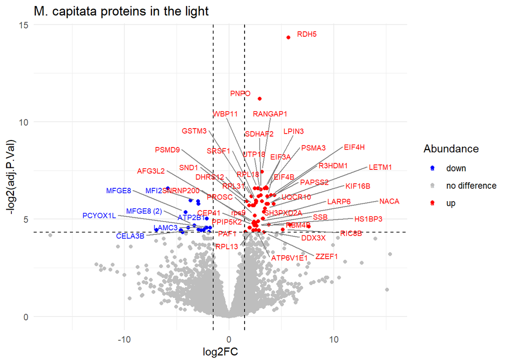

```r
volcano_plot <- ggplot(Mcap_DAP %>%
                         filter(!is.na(Abundance))%>%
                         mutate(Preferred_name = ifelse(Preferred_name == '-',NA,Given_name)),
                       aes(x = log2FC, y = -log2(adj.P.Val), color = Abundance)) +
  geom_point() +
  geom_hline(yintercept = -log2(0.05), linetype = "dashed", color = "black") +
  geom_vline(xintercept = c(-1.5, 1.5), linetype = "dashed", color = "black") +
  scale_color_manual(values = c("down" = "blue", "up" = "red", "no difference" = "grey")) +
  theme_minimal() +
  labs(title = "M. capitata proteins in the light") +
  geom_text_repel(aes(label = ifelse(Abundance != "no difference", Preferred_name, "")),
                  size = 2.5,
                  box.padding = 0.5,
                  point.padding = 0.5,
                  max.overlaps = Inf,
                  segment.color = "grey50")
volcano_plot
```

# Montipora capitata: down-regulation in the light

19 down-regulated proteins. Notice that two proteins are named MFGE8.

```r
Mcap_DAP %>%
  filter(Abundance == "down") %>%
  dplyr::select(Given_name)
```

```
## # A tibble: 19 × 1
##    Given_name
##    <chr>
##  1 Montipora_capitata_HIv3___TS.g15369.t1
##  2 Montipora_capitata_HIv3___TS.g19730.t1
##  3 MFI2
##  4 ATP2B1
##  5 MFGE8
##  6 Montipora_capitata_HIv3___RNAseq.g25589.t1
##  7 MFGE8 (2)
##  8 PCYOX1L
##  9 Montipora_capitata_HIv3___TS.g1769.t1
## 10 Montipora_capitata_HIv3___RNAseq.g19770.t2
## 11 LAMC3
## 12 CELA3B
## 13 Montipora_capitata_HIv3___RNAseq.g26627.t1
## 14 Montipora_capitata_HIv3___TS.g15014.t1
## 15 Montipora_capitata_HIv3___RNAseq.g30887.t1
## 16 Montipora_capitata_HIv3___RNAseq.g26668.t1
## 17 Montipora_capitata_HIv3___RNAseq.g33502.t1
## 18 Montipora_capitata_HIv3___RNAseq.g34981.t1
## 19 Montipora_capitata_HIv3___RNAseq.g35363.t1
```

Pick a term.

```r
colnames(Mcap_DAP)
```

```
##  [1] "Organism"       "name"           "Protein.Group"  "log2FC"
##  [5] "AveExpr"        "t"              "P.Value"        "adj.P.Val"
##  [9] "B"              "Abundance"      "KO"             "seed_ortholog"
## [13] "evalue"         "score"          "eggNOG_OGs"     "max_annot_lvl"
## [17] "COG_category"   "Description"    "Preferred_name" "GOs"
## [21] "EC"             "KEGG_ko"        "KEGG_Pathway"   "KEGG_Module"
## [25] "KEGG_Reaction"  "KEGG_rclass"    "BRITE"          "KEGG_TC"
## [29] "CAZy"           "BiGG_Reaction"  "PFAMs"          "Given_name"
```

Downregulation according to BRITE.

```r
# Background, proteins of interest and relevant term.
prot_rich_term <- Mcap_DAP %>%
  mutate(interest = Abundance == "down") %>%
  dplyr::rename(term = BRITE) %>%
  filter(!is.na(term)) %>%
  dplyr::select(name,adj.P.Val,log2FC,Abundance,interest,term)
# Terms associated with proteins.
term_df <- prot_rich_term %>%
  separate_rows(term, sep = ",")
# Term over-representation analysis.
term_enrich <- enricher(
  gene = prot_rich_term %>%
    filter(interest == TRUE) %>%
    dplyr::select(name) %>%
    unlist() %>%
    as.character(),
  TERM2GENE = term_df %>%
    dplyr::select(term,name),
  pAdjustMethod = "BH",
  qvalueCutoff = 0.01
)
term_enrich_result <- term_enrich@result
term_enrich
```

```
## #
## # over-representation test
## #
## #...@organism     UNKNOWN
## #...@ontology     UNKNOWN
## #...@gene     chr [1:16] "Montipora_capitata_HIv3___TS.g15369.t1" ...
## #...pvalues adjusted by 'BH' with cutoff <0.05
## #...2 enriched terms found
## 'data.frame':    2 obs. of  9 variables:
##  $ ID         : chr  "ko04090" "ko01002"
##  $ Description: chr  "ko04090" "ko01002"
##  $ GeneRatio  : chr  "3/16" "4/16"
##  $ BgRatio    : chr  "79/5199" "259/5199"
##  $ pvalue     : num  0.00164 0.00681
##  $ p.adjust   : num  0.00656 0.01362
##  $ qvalue     : num  0.00345 0.00717
##  $ geneID     : chr  "Montipora_capitata_HIv3___RNAseq.g10352.t1/Montipora_capitata_HIv3___RNAseq.g19770.t2/Montipora_capitata_HIv3__"| __truncated__ "Montipora_capitata_HIv3___RNAseq.g25589.t1/Montipora_capitata_HIv3___RNAseq.g19770.t2/Montipora_capitata_HIv3__"| __truncated__
##  $ Count      : int  3 4
## #...Citation
##  T Wu, E Hu, S Xu, M Chen, P Guo, Z Dai, T Feng, L Zhou, W Tang, L Zhan, X Fu, S Liu, X Bo, and G Yu.
##  clusterProfiler 4.0: A universal enrichment tool for interpreting omics data.
##  The Innovation. 2021, 2(3):100141
```

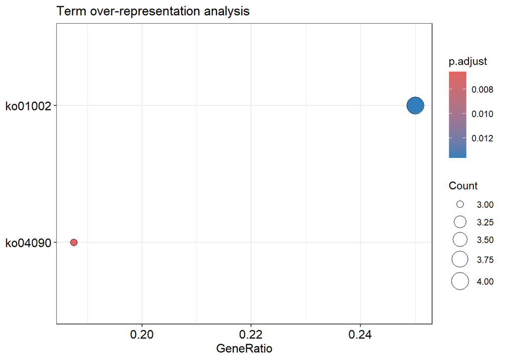

```r
# Dotplot for BRITE enrichment
Mcap_down_dotplot <- dotplot(term_enrich, showCategory=20) + ggtitle("Term over-representation analysis")
Mcap_down_dotplot
```

ko01002 means peptidase and inhibitors. ko04090 means CD molecules. Peptidases and inhibitors:

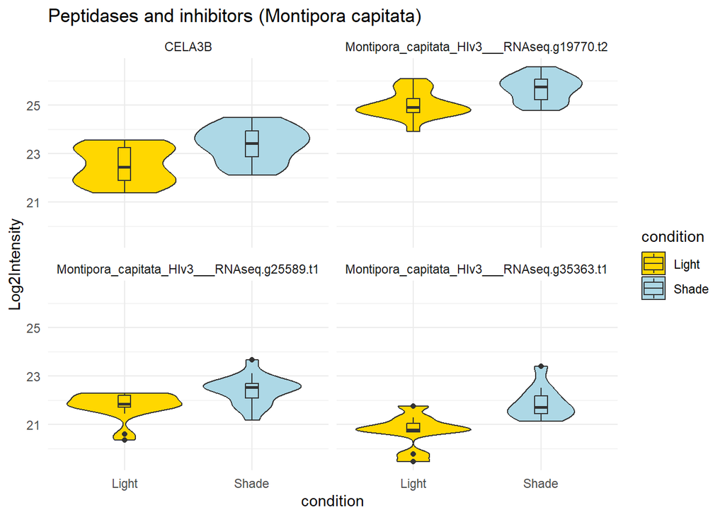

```r
peptidases_inhibitors_plot <- Mcap_DAP %>%
  filter(Abundance == "down", grepl("ko01002",BRITE)) %>%
  dplyr::select(name,Given_name) %>%
  left_join(prot_long %>% dplyr::select(name,Log2Intensity,condition,Genotype),by="name") %>%
  ggplot(aes(x=condition,y=Log2Intensity,fill=condition))+
  geom_violin() +
  geom_boxplot(width=0.1) +
  scale_fill_manual(values = c("Light" = "gold", "Shade" = "lightblue")) +
  facet_wrap(~Given_name) +
  theme_minimal() +
  labs(x="condition",
       title = "Peptidases and inhibitors (Montipora capitata)")
peptidases_inhibitors_plot
```

CD molecules.

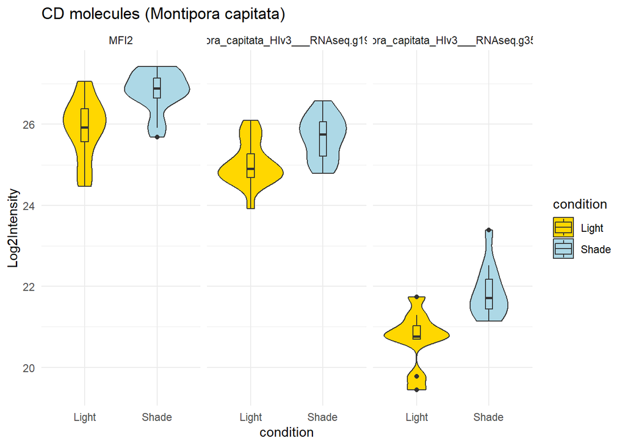

```r
peptidases_inhibitors_plot <- Mcap_DAP %>%
  filter(Abundance == "down", grepl("ko04090",BRITE)) %>%
  dplyr::select(name,Preferred_name) %>%
  mutate(Preferred_name = ifelse(Preferred_name == "-",name,Preferred_name)) %>%
  left_join(prot_long %>% dplyr::select(name,Log2Intensity,condition,Genotype),by="name") %>%
  ggplot(aes(x=condition,y=Log2Intensity,fill=condition))+
  geom_violin() +
  geom_boxplot(width=0.1) +
  scale_fill_manual(values = c("Light" = "gold", "Shade" = "lightblue")) +
  facet_wrap(~Preferred_name) +
  theme_minimal() +
  labs(x="condition",
       title = "CD molecules (Montipora capitata)")
peptidases_inhibitors_plot
```

Downregulation according to KEGG_Pathway: nothing detected.

```r
# Background, proteins of interest and relevant term.
prot_rich_term <- Mcap_DAP %>%
  mutate(interest = Abundance == "down") %>%
  dplyr::rename(term = KEGG_Pathway) %>%
  filter(!is.na(term)) %>%
  dplyr::select(name,adj.P.Val,log2FC,Abundance,interest,term)
# Terms associated with proteins.
term_df <- prot_rich_term %>%
  separate_rows(term, sep = ",")
# Term over-representation analysis.
term_enrich <- enricher(
  gene = prot_rich_term %>%
    filter(interest == TRUE) %>%
    dplyr::select(name) %>%
    unlist() %>%
    as.character(),
  TERM2GENE = term_df %>%
    dplyr::select(term,name),
  pAdjustMethod = "BH",
  qvalueCutoff = 0.01
)
term_enrich_result <- term_enrich@result
term_enrich
```

```
## #
## # over-representation test
## #
## #...@organism     UNKNOWN
## #...@ontology     UNKNOWN
## #...@gene     chr [1:16] "Montipora_capitata_HIv3___TS.g15369.t1" ...
## #...pvalues adjusted by 'BH' with cutoff <0.05
## #...0 enriched terms found
## #...Citation
##  T Wu, E Hu, S Xu, M Chen, P Guo, Z Dai, T Feng, L Zhou, W Tang, L Zhan, X Fu, S Liu, X Bo, and G Yu.
##  clusterProfiler 4.0: A universal enrichment tool for interpreting omics data.
##  The Innovation. 2021, 2(3):100141
```

Down-regulation according to GO terms (biological process).

```r
# GO dataframe
prot_rich_GO <- Mcap_DAP %>%
  mutate(interest = as.numeric(Abundance == "down")) %>%
  filter(!is.na(GOs)) %>%
  dplyr::select(name,adj.P.Val,log2FC,Abundance,interest,GOs)
# Named vector of genes
genesList <- setNames(prot_rich_GO$interest,
                     prot_rich_GO$name)
head(genesList)
```

```
## Montipora_capitata_HIv3___RNAseq.g22991.t1
##                                          0
##  Montipora_capitata_HIv3___RNAseq.g1539.t1
##                                          0
## Montipora_capitata_HIv3___RNAseq.g26613.t1
##                                          0
##     Montipora_capitata_HIv3___TS.g37235.t2
##                                          0
## Montipora_capitata_HIv3___RNAseq.g38871.t1
##                                          0
## Montipora_capitata_HIv3___RNAseq.g15080.t1
##                                          0
```

```r
# GO terms
GO_df <- prot_rich_GO %>%
  separate_rows(GOs, sep = ",") %>%
  dplyr::select(name,GOs)
gene2GO <- split(GO_df$GOs,GO_df$name)
# GOdata object
GOdata <- new("topGOdata",
              description = "Simple session",
              ontology = "BP",
              allGenes = genesList,
              geneSelectionFun = function(x) x == 1,
              annot = annFUN.gene2GO,
              gene2GO = gene2GO)
```

```
##
## Building most specific GOs .....
```

```
##  ( 11696 GO terms found. )
```

```
##
## Build GO DAG topology ..........
```

```
##  ( 12125 GO terms and 27123 relations. )
```

```
##
## Annotating nodes ...............
```

```
##  ( 3673 genes annotated to the GO terms. )
```

```r
# Fisher test
resultFisher <- runTest(GOdata, algorithm = "classic", statistic = "fisher")
```

```
##
##           -- Classic Algorithm --
##
##       the algorithm is scoring 740 nontrivial nodes
##       parameters:
##           test statistic: fisher
```

```r
# Top 20
allGO <- usedGO(GOdata)
allRes <- GenTable(GOdata, classicFisher = resultFisher, orderBy = "classicFisher", topNodes = 20)
# Match to data
GOs_different <- allRes %>%
  rowwise() %>%
  mutate(
    Proteins = Mcap_DAP %>%
      filter(Abundance == "down", grepl(GO.ID, GOs)) %>%
      pull(Given_name) %>%
      paste(collapse = ", ")
  ) %>%
  ungroup()
GOs_different
```

```
## # A tibble: 20 × 7
##    GO.ID      Term         Annotated Significant Expected classicFisher Proteins
##    <chr>      <chr>            <int>       <int>    <dbl> <chr>         <chr>
##  1 GO:0006910 phagocytosi…         9           2       NA 0.00011       MFGE8, …
##  2 GO:0045807 positive re…        96           3       NA 0.00056       ATP2B1,…
##  3 GO:0050906 detection o…        28           2       NA 0.00115       ATP2B1,…
##  4 GO:0022617 extracellul…        31           2       NA 0.00141       LAMC3
##  5 GO:0043627 response to…        32           2       NA 0.00150       MFGE8, …
##  6 GO:0030327 prenylated …         1           1       NA 0.00191       PCYOX1L
##  7 GO:0030328 prenylcyste…         1           1       NA 0.00191       PCYOX1L
##  8 GO:0030329 prenylcyste…         1           1       NA 0.00191       PCYOX1L
##  9 GO:0030100 regulation …       149           3       NA 0.00203       ATP2B1,…
## 10 GO:0034446 substrate a…        40           2       NA 0.00235       LAMC3
## 11 GO:0050766 positive re…        40           2       NA 0.00235       MFGE8, …
## 12 GO:0006911 phagocytosi…        41           2       NA 0.00246       MFGE8, …
## 13 GO:0043687 post-transl…       363           4       NA 0.00258       MFI2, M…
## 14 GO:0019538 protein met…      1607           7       NA 0.00305       MFI2, M…
## 15 GO:0099024 plasma memb…        49           2       NA 0.00351       MFGE8, …
## 16 GO:0043277 apoptotic c…        51           2       NA 0.00380       MFGE8, …
## 17 GO:0045299 otolith min…         2           1       NA 0.00381       ATP2B1
## 18 GO:0071386 cellular re…         2           1       NA 0.00381       ATP2B1
## 19 GO:0009581 detection o…        52           2       NA 0.00395       ATP2B1,…
## 20 GO:0009582 detection o…        52           2       NA 0.00395       ATP2B1,…
```

```r
# Visualization
allRes$Term <- paste(allRes$GO.ID, allRes$Term, sep = ": ")
allRes <- allRes %>%
  mutate(pvalue = -log10(as.numeric(classicFisher)),
         Term = factor(Term, levels = unique(Term[order(pvalue)])))
pdf("Up-regulation of M. capitata BP in low light.pdf")
graph_plot <- showSigOfNodes(GOdata, score(resultFisher), firstSigNodes = 20, useInfo = "all")
dev.off()
```

```r
graph_plot
```

```
## $dag
## A graphNEL graph with directed edges
## Number of Nodes = 117
## Number of Edges = 195
##
## $complete.dag
## [1] "A graph with 117 nodes."
```

```r
GO_enrichment_plot <- ggplot(allRes, aes(x = pvalue, y = Term)) +
    geom_point(aes(size = Significant)) +
    theme_minimal() +
    labs(title = "Up-regulation of M. capitata BP in low light",
         x = "-log10(p-value)",
         y = "Significant GO terms",
         size = "Protein total")
    theme(axis.text.y = element_text(size = 10),
          axis.title = element_text(size = 12),
          plot.title = element_text(hjust = 0.5, size = 14))
```

[output not shown]

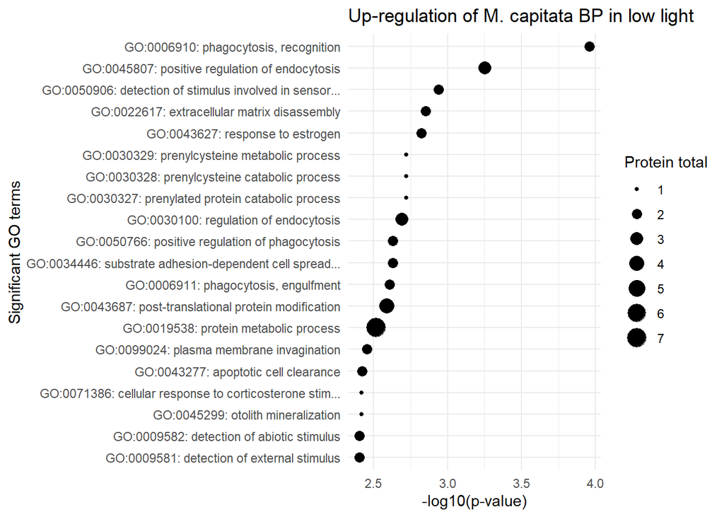

```r
GO_enrichment_plot
```

Downregulation according to GO terms (molecular function).

```r
# GO dataframe
prot_rich_GO <- Mcap_DAP %>%
  mutate(interest = as.numeric(Abundance == "down")) %>%
  filter(!is.na(GOs)) %>%
  dplyr::select(name,adj.P.Val,log2FC,Abundance,interest,GOs)
# Named vector of genes
genesList <- setNames(prot_rich_GO$interest,
                     prot_rich_GO$name)
head(genesList)
```

```
## Montipora_capitata_HIv3___RNAseq.g22991.t1
##                                          0
##  Montipora_capitata_HIv3___RNAseq.g1539.t1
##                                          0
## Montipora_capitata_HIv3___RNAseq.g26613.t1
##                                          0
##     Montipora_capitata_HIv3___TS.g37235.t2
##                                          0
## Montipora_capitata_HIv3___RNAseq.g38871.t1
##                                          0
## Montipora_capitata_HIv3___RNAseq.g15080.t1
##                                          0
```

```r
# GO terms
GO_df <- prot_rich_GO %>%
  separate_rows(GOs, sep = ",") %>%
  dplyr::select(name,GOs)
gene2GO <- split(GO_df$GOs,GO_df$name)
# GOdata object
GOdata <- new("topGOdata",
              description = "Simple session",
              ontology = "MF",
              allGenes = genesList,
              geneSelectionFun = function(x) x == 1,
              annot = annFUN.gene2GO,
              gene2GO = gene2GO)
```

```
##
## Building most specific GOs .....
```

```
##  ( 2733 GO terms found. )
```

```
##
## Build GO DAG topology ..........
```

```
##  ( 2799 GO terms and 3589 relations. )
```

```
##
## Annotating nodes ...............
```

```
##  ( 3341 genes annotated to the GO terms. )
```

```r
# Fisher test
resultFisher <- runTest(GOdata, algorithm = "classic", statistic = "fisher")
```

```
##
##           -- Classic Algorithm --
##
##       the algorithm is scoring 96 nontrivial nodes
##       parameters:
##           test statistic: fisher
```

```r
# Top 20
allGO <- usedGO(GOdata)
allRes <- GenTable(GOdata, classicFisher = resultFisher, orderBy = "classicFisher", topNodes = 20)
# Match to data
GOs_different <- allRes %>%
  rowwise() %>%
  mutate(
    Proteins = Mcap_DAP %>%
      filter(Abundance == "down", grepl(GO.ID, GOs)) %>%
      pull(Given_name) %>%
      paste(collapse = ", ")
  ) %>%
  ungroup()
GOs_different
```

```
## # A tibble: 20 × 7
##    GO.ID      Term         Annotated Significant Expected classicFisher Proteins
##    <chr>      <chr>            <int>       <int>    <dbl> <chr>         <chr>
##  1 GO:0008429 phosphatidy…         8           2       NA 0.0001        MFGE8, …
##  2 GO:0001786 phosphatidy…        17           2       NA 0.0005        MFGE8, …
##  3 GO:0072341 modified am…        33           2       NA 0.0019        MFGE8, …
##  4 GO:0001735 prenylcyste…         1           1       NA 0.0021        PCYOX1L
##  5 GO:0005178 integrin bi…        41           2       NA 0.0030        MFGE8, …
##  6 GO:0043208 glycosphing…         2           1       NA 0.0042        LAMC3
##  7 GO:0042626 ATPase-coup…        54           2       NA 0.0051        ATP2B1,…
##  8 GO:0008289 lipid bindi…       198           3       NA 0.0060        MFGE8, …
##  9 GO:0036487 nitric-oxid…         3           1       NA 0.0063        ATP2B1
## 10 GO:0016670 oxidoreduct…         4           1       NA 0.0084        PCYOX1L
## 11 GO:0030899 calcium-dep…         4           1       NA 0.0084        ATP2B1
## 12 GO:0030235 nitric-oxid…         5           1       NA 0.0104        ATP2B1
## 13 GO:0051861 glycolipid …         5           1       NA 0.0104        LAMC3
## 14 GO:0015399 primary act…        78           2       NA 0.0105        ATP2B1,…
## 15 GO:0050839 cell adhesi…        79           2       NA 0.0107        MFGE8, …
## 16 GO:0005388 P-type calc…         6           1       NA 0.0125        ATP2B1
## 17 GO:0033130 acetylcholi…         6           1       NA 0.0125        ATP2B1
## 18 GO:0046625 sphingolipi…         6           1       NA 0.0125        LAMC3
## 19 GO:0005201 extracellul…         7           1       NA 0.0146        LAMC3
## 20 GO:0030346 protein pho…         7           1       NA 0.0146        ATP2B1
```

```r
# Visualization
allRes$Term <- paste(allRes$GO.ID, allRes$Term, sep = ": ")
allRes <- allRes %>%
  mutate(pvalue = -log10(as.numeric(classicFisher)),
         Term = factor(Term, levels = unique(Term[order(pvalue)])))
pdf("Up-regulation of M. capitata MF in low light.pdf")
graph_plot <- showSigOfNodes(GOdata, score(resultFisher), firstSigNodes = 20, useInfo = "all")
dev.off()
```

```r
GO_enrichment_plot <- ggplot(allRes, aes(x = pvalue, y = Term)) +
    geom_point(aes(size = Significant)) +
    theme_minimal() +
    labs(title = "Up-regulation of M. capitata MF in low light",
         x = "-log10(p-value)",
         y = "Significant GO terms",
         size = "Protein total")
    theme(axis.text.y = element_text(size = 10),
          axis.title = element_text(size = 12),
          plot.title = element_text(hjust = 0.5, size = 14))
```

[output not shown]

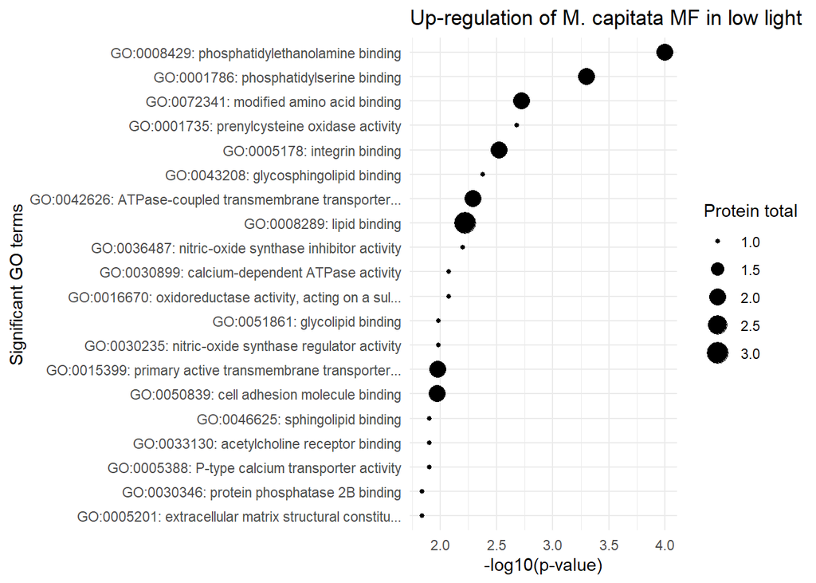

```r
GO_enrichment_plot
```

Downregulation according to GO terms (cellular component).

```r
# GO dataframe
prot_rich_GO <- Mcap_DAP %>%
  mutate(interest = as.numeric(Abundance == "down")) %>%
  filter(!is.na(GOs)) %>%
  dplyr::select(name,adj.P.Val,log2FC,Abundance,interest,GOs)
# Named vector of genes
genesList <- setNames(prot_rich_GO$interest,
                     prot_rich_GO$name)
head(genesList)
```

```
## Montipora_capitata_HIv3___RNAseq.g22991.t1
##                                          0
##  Montipora_capitata_HIv3___RNAseq.g1539.t1
##                                          0
## Montipora_capitata_HIv3___RNAseq.g26613.t1
##                                          0
##     Montipora_capitata_HIv3___TS.g37235.t2
##                                          0
## Montipora_capitata_HIv3___RNAseq.g38871.t1
##                                          0
## Montipora_capitata_HIv3___RNAseq.g15080.t1
##                                          0
```

```r
# GO terms
GO_df <- prot_rich_GO %>%
  separate_rows(GOs, sep = ",") %>%
  dplyr::select(name,GOs)
gene2GO <- split(GO_df$GOs,GO_df$name)
# GOdata object
GOdata <- new("topGOdata",
              description = "Simple session",
              ontology = "CC",
              allGenes = genesList,
              geneSelectionFun = function(x) x == 1,
              annot = annFUN.gene2GO,
              gene2GO = gene2GO)
```

```
##
## Building most specific GOs .....
```

```
##  ( 1501 GO terms found. )
```

```
##
## Build GO DAG topology ..........
```

```
##  ( 1508 GO terms and 2556 relations. )
```

```
##
## Annotating nodes ...............
```

```
##  ( 3657 genes annotated to the GO terms. )
```

```r
# Fisher test
resultFisher <- runTest(GOdata, algorithm = "classic", statistic = "fisher")
```

```
##
##           -- Classic Algorithm --
##
##       the algorithm is scoring 122 nontrivial nodes
##       parameters:
##           test statistic: fisher
```

```r
# Top 20
allGO <- usedGO(GOdata)
allRes <- GenTable(GOdata, classicFisher = resultFisher, orderBy = "classicFisher", topNodes = 20)
# Match to data
GOs_different <- allRes %>%
  rowwise() %>%
  mutate(
    Proteins = Mcap_DAP %>%
      filter(Abundance == "down", grepl(GO.ID, GOs)) %>%
      pull(Given_name) %>%
      paste(collapse = ", ")
  ) %>%
  ungroup()
GOs_different
```

```
## # A tibble: 20 × 7
##    GO.ID      Term         Annotated Significant Expected classicFisher Proteins
##    <chr>      <chr>            <int>       <int>    <dbl> <chr>         <chr>
##  1 GO:0005788 endoplasmic…        87           4       NA 9.9e-06       MFI2, M…
##  2 GO:0005615 extracellul…       219           5       NA 1.4e-05       MFGE8, …
##  3 GO:0005576 extracellul…       458           6       NA 2.3e-05       MFI2, M…
##  4 GO:0005783 endoplasmic…       556           5       NA 0.0013        MFI2, A…
##  5 GO:0005606 laminin-1 c…         1           1       NA 0.0019        LAMC3
##  6 GO:0034361 very-low-de…         1           1       NA 0.0019        PCYOX1L
##  7 GO:0071944 cell periph…      1000           6       NA 0.0022        MFI2, A…
##  8 GO:0009986 cell surface       153           3       NA 0.0022        MFI2, M…
##  9 GO:0098552 side of mem…       161           3       NA 0.0026        ATP2B1,…
## 10 GO:0009897 external si…        50           2       NA 0.0037        MFGE8, …
## 11 GO:0034385 triglycerid…         2           1       NA 0.0038        PCYOX1L
## 12 GO:0043256 laminin com…         2           1       NA 0.0038        LAMC3
## 13 GO:0043259 laminin-10 …         2           1       NA 0.0038        LAMC3
## 14 GO:0043260 laminin-11 …         2           1       NA 0.0038        LAMC3
## 15 GO:0032591 dendritic s…         3           1       NA 0.0057        ATP2B1
## 16 GO:0032994 protein-lip…         3           1       NA 0.0057        PCYOX1L
## 17 GO:0034358 plasma lipo…         3           1       NA 0.0057        PCYOX1L
## 18 GO:1990777 lipoprotein…         3           1       NA 0.0057        PCYOX1L
## 19 GO:0019897 extrinsic c…        67           2       NA 0.0065        MFGE8, …
## 20 GO:0098839 postsynapti…         4           1       NA 0.0076        ATP2B1
```

```r
# Visualization
allRes$Term <- paste(allRes$GO.ID, allRes$Term, sep = ": ")
allRes <- allRes %>%
  mutate(pvalue = -log10(as.numeric(classicFisher)),
         Term = factor(Term, levels = unique(Term[order(pvalue)])))
pdf("Up-regulation of M. capitata CC in low light.pdf")
graph_plot <- showSigOfNodes(GOdata, score(resultFisher), firstSigNodes = 20, useInfo = "all")
dev.off()
```

```r
GO_enrichment_plot <- ggplot(allRes, aes(x = pvalue, y = Term)) +
    geom_point(aes(size = Significant)) +
    theme_minimal() +
    labs(title = "Up-regulation of M. capitata CC in low light",
         x = "-log10(p-value)",
         y = "Significant GO terms",
         size = "Protein total")
    theme(axis.text.y = element_text(size = 10),
          axis.title = element_text(size = 12),
          plot.title = element_text(hjust = 0.5, size = 14))
```

[output not shown]

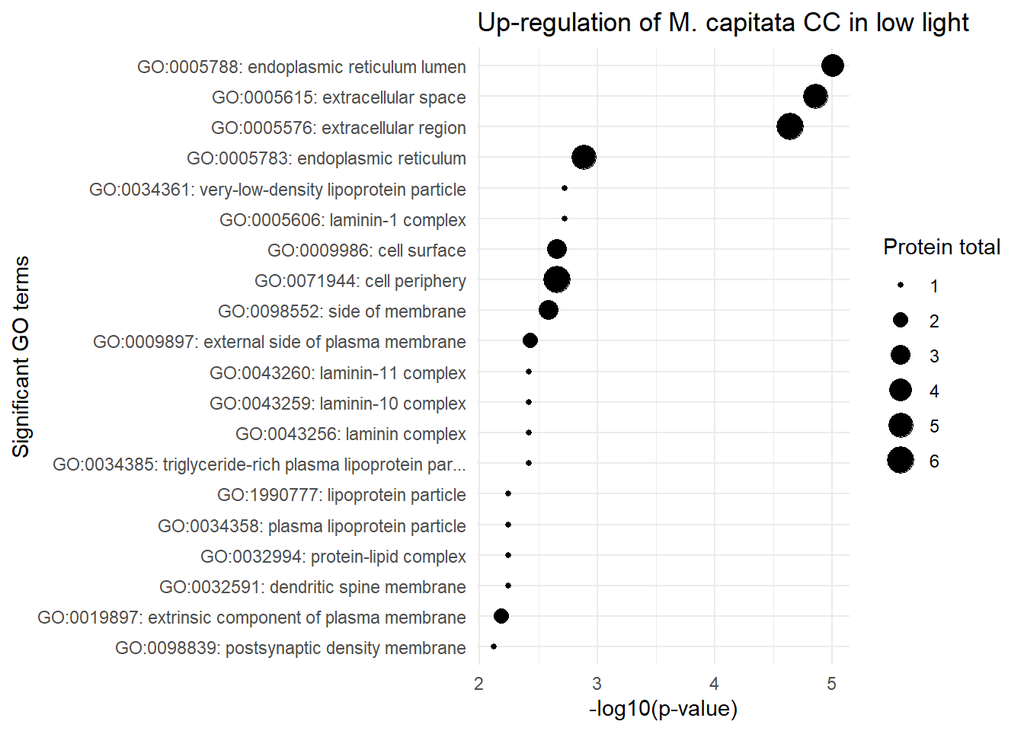

```r
GO_enrichment_plot
```

Take-home message: - membrane proteins (CC) - transporter activity (MF) - immunity ? (BRITE) - proteolytic processes? (BP)

# Montipora capitata: up-regulation in the light

Pick a term.

```r
colnames(Mcap_DAP)
```

```
##  [1] "Organism"       "name"           "Protein.Group"  "log2FC"
##  [5] "AveExpr"        "t"              "P.Value"        "adj.P.Val"
##  [9] "B"              "Abundance"      "KO"             "seed_ortholog"
## [13] "evalue"         "score"          "eggNOG_OGs"     "max_annot_lvl"
## [17] "COG_category"   "Description"    "Preferred_name" "GOs"
## [21] "EC"             "KEGG_ko"        "KEGG_Pathway"   "KEGG_Module"
## [25] "KEGG_Reaction"  "KEGG_rclass"    "BRITE"          "KEGG_TC"
## [29] "CAZy"           "BiGG_Reaction"  "PFAMs"          "Given_name"
```

Up-regulation according to BRITE: nothing detected.

```r
# Background, proteins of interest and relevant term.
prot_rich_term <- Mcap_DAP %>%
  mutate(interest = Abundance == "up") %>%
  dplyr::rename(term = BRITE) %>%
  filter(!is.na(term)) %>%
  dplyr::select(name,adj.P.Val,log2FC,Abundance,interest,term)
# Terms associated with proteins.
term_df <- prot_rich_term %>%
  separate_rows(term, sep = ",")
# Term over-representation analysis.
term_enrich <- enricher(
  gene = prot_rich_term %>%
    filter(interest == TRUE) %>%
    dplyr::select(name) %>%
    unlist() %>%
    as.character(),
  TERM2GENE = term_df %>%
    dplyr::select(term,name),
  pAdjustMethod = "BH",
  qvalueCutoff = 0.01
)
term_enrich_result <- term_enrich@result
term_enrich
```

```
## #
## # over-representation test
## #
## #...@organism     UNKNOWN
## #...@ontology     UNKNOWN
## #...@gene     chr [1:46] "Montipora_capitata_HIv3___RNAseq.g22991.t1" ...
## #...pvalues adjusted by 'BH' with cutoff <0.05
## #...0 enriched terms found
## #...Citation
##  T Wu, E Hu, S Xu, M Chen, P Guo, Z Dai, T Feng, L Zhou, W Tang, L Zhan, X Fu, S Liu, X Bo, and G Yu.
##  clusterProfiler 4.0: A universal enrichment tool for interpreting omics data.
##  The Innovation. 2021, 2(3):100141
```

Up-regulation according to KEGG_Pathway: nothing detected.

```r
# Background, proteins of interest and relevant term.
prot_rich_term <- Mcap_DAP %>%
  mutate(interest = Abundance == "up") %>%
  dplyr::rename(term = KEGG_Pathway) %>%
  filter(!is.na(term)) %>%
  dplyr::select(name,adj.P.Val,log2FC,Abundance,interest,term)
# Terms associated with proteins.
term_df <- prot_rich_term %>%
  separate_rows(term, sep = ",")
# Term over-representation analysis.
term_enrich <- enricher(
  gene = prot_rich_term %>%
    filter(interest == TRUE) %>%
    dplyr::select(name) %>%
    unlist() %>%
    as.character(),
  TERM2GENE = term_df %>%
    dplyr::select(term,name),
  pAdjustMethod = "BH",
  qvalueCutoff = 0.01
)
term_enrich_result <- term_enrich@result
term_enrich
```

```
## #
## # over-representation test
## #
## #...@organism     UNKNOWN
## #...@ontology     UNKNOWN
## #...@gene     chr [1:46] "Montipora_capitata_HIv3___RNAseq.g22991.t1" ...
## #...pvalues adjusted by 'BH' with cutoff <0.05
## #...0 enriched terms found
## #...Citation
##  T Wu, E Hu, S Xu, M Chen, P Guo, Z Dai, T Feng, L Zhou, W Tang, L Zhan, X Fu, S Liu, X Bo, and G Yu.
##  clusterProfiler 4.0: A universal enrichment tool for interpreting omics data.
##  The Innovation. 2021, 2(3):100141
```

Up-regulation according to GO terms (biological process).

```r
# GO dataframe
prot_rich_GO <- Mcap_DAP %>%
  mutate(interest = as.numeric(Abundance == "up")) %>%
  filter(!is.na(GOs)) %>%
  dplyr::select(name,adj.P.Val,log2FC,Abundance,interest,GOs)
# Named vector of genes
genesList <- setNames(prot_rich_GO$interest,
                     prot_rich_GO$name)
head(genesList)
```

```
## Montipora_capitata_HIv3___RNAseq.g22991.t1
##                                          1
##  Montipora_capitata_HIv3___RNAseq.g1539.t1
##                                          1
## Montipora_capitata_HIv3___RNAseq.g26613.t1
##                                          1
##     Montipora_capitata_HIv3___TS.g37235.t2
##                                          1
## Montipora_capitata_HIv3___RNAseq.g38871.t1
##                                          1
## Montipora_capitata_HIv3___RNAseq.g15080.t1
##                                          1
```

```r
# GO terms
GO_df <- prot_rich_GO %>%
  separate_rows(GOs, sep = ",") %>%
  dplyr::select(name,GOs)
gene2GO <- split(GO_df$GOs,GO_df$name)
# GOdata object
GOdata <- new("topGOdata",
              description = "Simple session",
              ontology = "BP",
              allGenes = genesList,
              geneSelectionFun = function(x) x == 1,
              annot = annFUN.gene2GO,
              gene2GO = gene2GO)
```

```
##
## Building most specific GOs .....
```

```
##  ( 11696 GO terms found. )
```

```
##
## Build GO DAG topology ..........
```

```
##  ( 12125 GO terms and 27123 relations. )
```

```
##
## Annotating nodes ...............
```

```
##  ( 3673 genes annotated to the GO terms. )
```

```r
# Fisher test
resultFisher <- runTest(GOdata, algorithm = "classic", statistic = "fisher")
```

```
##
##           -- Classic Algorithm --
##
##       the algorithm is scoring 1394 nontrivial nodes
##       parameters:
##           test statistic: fisher
```

```r
# Top 20
allGO <- usedGO(GOdata)
allRes <- GenTable(GOdata, classicFisher = resultFisher, orderBy = "classicFisher", topNodes = 20)
# Identifications
GOs_different <- allRes %>%
  rowwise() %>%
  mutate(
    Proteins = Mcap_DAP %>%
      filter(Abundance == "up", grepl(GO.ID, GOs)) %>%
      pull(Given_name) %>%
      paste(collapse = ", ")
  ) %>%
  ungroup()
GOs_different
```

```
## # A tibble: 20 × 7
##    GO.ID      Term         Annotated Significant Expected classicFisher Proteins
##    <chr>      <chr>            <int>       <int>    <dbl> <chr>         <chr>
##  1 GO:0002181 cytoplasmic…        88           8       NA 2.6e-06       EIF3A, …
##  2 GO:0002183 cytoplasmic…        18           4       NA 3.0e-05       EIF3A, …
##  3 GO:0006446 regulation …        40           5       NA 5.2e-05       EIF3A, …
##  4 GO:0006413 translation…       106           7       NA 9.8e-05       EIF3A, …
##  5 GO:0097010 eukaryotic …         2           2       NA 0.00011       EIF4H, …
##  6 GO:0006412 translation        290          11       NA 0.00014       EIF3A, …
##  7 GO:0045292 mRNA cis sp…        11           3       NA 0.00017       WBP11, …
##  8 GO:0043043 peptide bio…       312          11       NA 0.00027       EIF3A, …
##  9 GO:0006417 regulation …       158           7       NA 0.00115       EIF3A, …
## 10 GO:0006518 peptide met…       371          11       NA 0.00119       EIF3A, …
## 11 GO:0043604 amide biosy…       376          11       NA 0.00133       EIF3A, …
## 12 GO:1903608 protein loc…         6           2       NA 0.00160       SSB, DD…
## 13 GO:0022618 protein-RNA…       134           6       NA 0.00255       EIF3A, …
## 14 GO:0034248 regulation …       185           7       NA 0.00286       EIF3A, …
## 15 GO:0071826 protein-RNA…       142           6       NA 0.00341       EIF3A, …
## 16 GO:0010608 post-transc…       244           8       NA 0.00343       EIF3A, …
## 17 GO:0001731 formation o…        11           2       NA 0.00569       EIF4H, …
## 18 GO:0051560 mitochondri…        11           2       NA 0.00569       LETM1, …
## 19 GO:0065007 biological …      2634          35       NA 0.00606       RDH5, R…
## 20 GO:0022613 ribonucleop…       214           7       NA 0.00642       EIF3A, …
```

```r
# Visualization
allRes$Term <- paste(allRes$GO.ID, allRes$Term, sep = ": ")
allRes <- allRes %>%
  mutate(pvalue = -log10(as.numeric(classicFisher)),
         Term = factor(Term, levels = unique(Term[order(pvalue)])))
pdf("Up-regulation of M. capitata BP in high light.pdf")
graph_plot <- showSigOfNodes(GOdata, score(resultFisher), firstSigNodes = 20, useInfo = "all")
dev.off()
```

```r
graph_plot
```

```
## $dag
## A graphNEL graph with directed edges
## Number of Nodes = 87
## Number of Edges = 148
##
## $complete.dag
## [1] "A graph with 87 nodes."
```

```r
GO_enrichment_plot <- ggplot(allRes, aes(x = pvalue, y = Term)) +
    geom_point(aes(size = Significant)) +
    theme_minimal() +
    labs(title = "Up-regulation of M. capitata BP in high light",
         x = "-log10(p-value)",
         y = "Significant GO terms",
         size = "Protein total")
    theme(axis.text.y = element_text(size = 10),
          axis.title = element_text(size = 12),
          plot.title = element_text(hjust = 0.5, size = 14))
```

[output not shown]

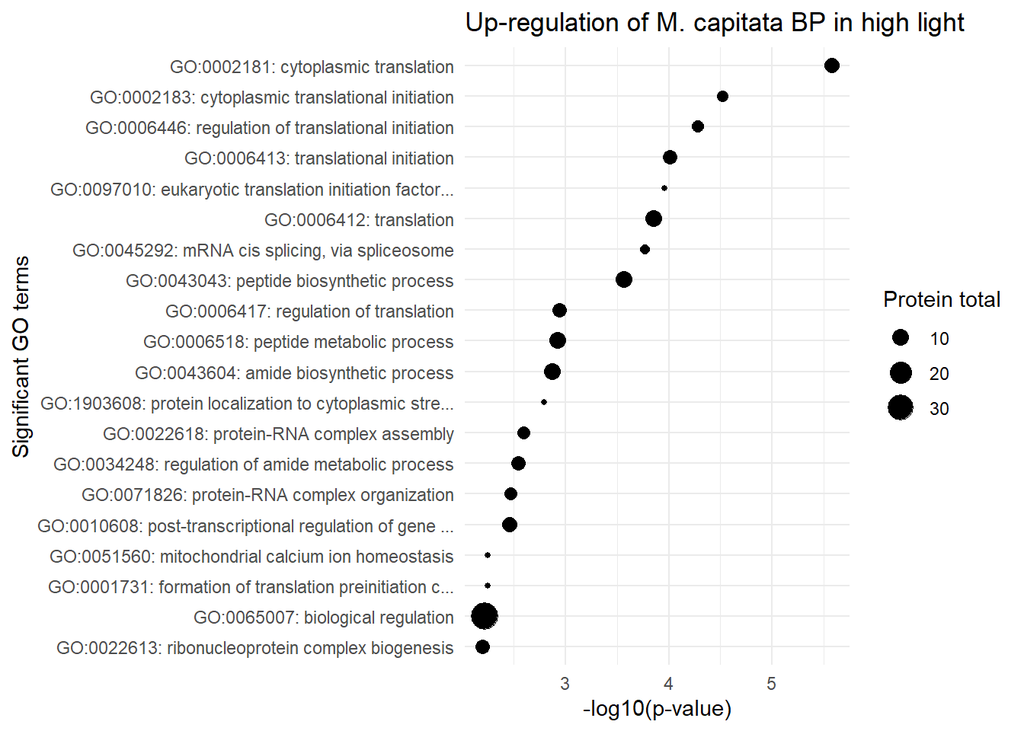

```r
GO_enrichment_plot
```

Very clear signal of translation.

Up-regulation according to GO terms (molecular function).

```r
# GO dataframe
prot_rich_GO <- Mcap_DAP %>%
  mutate(interest = as.numeric(Abundance == "up")) %>%
  filter(!is.na(GOs)) %>%
  dplyr::select(name,adj.P.Val,log2FC,Abundance,interest,GOs)
# Named vector of genes
genesList <- setNames(prot_rich_GO$interest,
                     prot_rich_GO$name)
head(genesList)
```

```
## Montipora_capitata_HIv3___RNAseq.g22991.t1
##                                          1
##  Montipora_capitata_HIv3___RNAseq.g1539.t1
##                                          1
## Montipora_capitata_HIv3___RNAseq.g26613.t1
##                                          1
##     Montipora_capitata_HIv3___TS.g37235.t2
##                                          1
## Montipora_capitata_HIv3___RNAseq.g38871.t1
##                                          1
## Montipora_capitata_HIv3___RNAseq.g15080.t1
##                                          1
```

```r
# GO terms
GO_df <- prot_rich_GO %>%
  separate_rows(GOs, sep = ",") %>%
  dplyr::select(name,GOs)
gene2GO <- split(GO_df$GOs,GO_df$name)
# GOdata object
GOdata <- new("topGOdata",
              description = "Simple session",
              ontology = "MF",
              allGenes = genesList,
              geneSelectionFun = function(x) x == 1,
              annot = annFUN.gene2GO,
              gene2GO = gene2GO)
```

```
##
## Building most specific GOs .....
```

```
##  ( 2733 GO terms found. )
```

```
##
## Build GO DAG topology ..........
```

```
##  ( 2799 GO terms and 3589 relations. )
```

```
##
## Annotating nodes ...............
```

```
##  ( 3341 genes annotated to the GO terms. )
```

```r
# Fisher test
resultFisher <- runTest(GOdata, algorithm = "classic", statistic = "fisher")
```

```
##
##           -- Classic Algorithm --
##
##       the algorithm is scoring 231 nontrivial nodes
##       parameters:
##           test statistic: fisher
```

```r
# Top 20
allGO <- usedGO(GOdata)
allRes <- GenTable(GOdata, classicFisher = resultFisher, orderBy = "classicFisher", topNodes = 20)
# Identifications
GOs_different <- allRes %>%
  rowwise() %>%
  mutate(
    Proteins = Mcap_DAP %>%
      filter(Abundance == "up", grepl(GO.ID, GOs)) %>%
      pull(Given_name) %>%
      paste(collapse = ", ")
  ) %>%
  ungroup()
GOs_different
```

```
## # A tibble: 20 × 7
##    GO.ID      Term         Annotated Significant Expected classicFisher Proteins
##    <chr>      <chr>            <int>       <int>    <dbl> <chr>         <chr>
##  1 GO:0033592 RNA strand …         4           3       NA 5e-06         "EIF4H,…
##  2 GO:0140666 annealing a…         4           3       NA 5e-06         ""
##  3 GO:0043024 ribosomal s…         9           3       NA 0.00010       "EIF4H,…
##  4 GO:0034057 RNA strand-…         2           2       NA 0.00012       "EIF4H,…
##  5 GO:0003723 RNA binding        407          13       NA 0.00024       "RANGAP…
##  6 GO:0003729 mRNA binding       161           8       NA 0.00028       "EIF3A,…
##  7 GO:0032266 phosphatidy…        19           3       NA 0.00107       "KIF16B…
##  8 GO:1990825 sequence-sp…         7           2       NA 0.00242       "LARP6,…
##  9 GO:0003727 single-stra…        55           4       NA 0.00290       "EIF4H,…
## 10 GO:0004386 helicase ac…        55           4       NA 0.00290       "EIF4H,…
## 11 GO:0003725 double-stra…        32           3       NA 0.00497       "EIF4H,…
## 12 GO:0043325 phosphatidy…        10           2       NA 0.00508       "KIF16B…
## 13 GO:0015078 proton tran…        34           3       NA 0.00591       "LETM1,…
## 14 GO:0003743 translation…        36           3       NA 0.00694       "EIF3A,…
## 15 GO:0043022 ribosome bi…        37           3       NA 0.00750       ""
## 16 GO:0035613 RNA stem-lo…        13           2       NA 0.00862       "LARP6,…
## 17 GO:0003676 nucleic aci…       609          13       NA 0.01054       "RANGAP…
## 18 GO:0000832 inositol he…         1           1       NA 0.01107       "PPIP5K…
## 19 GO:0004020 adenylylsul…         1           1       NA 0.01107       "PAPSS2"
## 20 GO:0004733 pyridoxamin…         1           1       NA 0.01107       "PNPO"
```

```r
# Visualization
allRes$Term <- paste(allRes$GO.ID, allRes$Term, sep = ": ")
allRes <- allRes %>%
  mutate(pvalue = -log10(as.numeric(classicFisher)),
         Term = factor(Term, levels = unique(Term[order(pvalue)])))
pdf("Up-regulation of M. capitata MF in high light.pdf")
graph_plot <- showSigOfNodes(GOdata, score(resultFisher), firstSigNodes = 20, useInfo = "all")
dev.off()
```

```r
GO_enrichment_plot <- ggplot(allRes, aes(x = pvalue, y = Term)) +
    geom_point(aes(size = Significant)) +
    theme_minimal() +
    labs(title = "Up-regulation of M. capitata MF in high light",
         x = "-log10(p-value)",
         y = "Significant GO terms",
         size = "Protein total")
    theme(axis.text.y = element_text(size = 10),
          axis.title = element_text(size = 12),
          plot.title = element_text(hjust = 0.5, size = 14))
```

[output not shown]

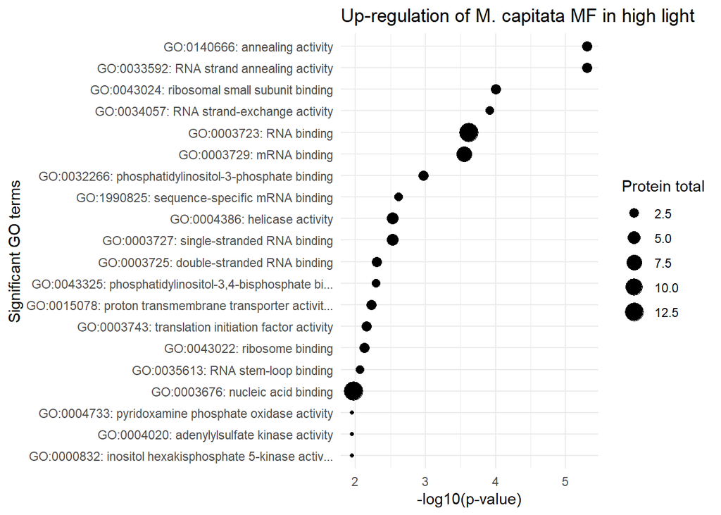

```r
GO_enrichment_plot
```

Ribosomes, translation.

```r
# GO dataframe
prot_rich_GO <- Mcap_DAP %>%
  mutate(interest = as.numeric(Abundance == "up")) %>%
  filter(!is.na(GOs)) %>%
  dplyr::select(name,adj.P.Val,log2FC,Abundance,interest,GOs)
# Named vector of genes
genesList <- setNames(prot_rich_GO$interest,
                     prot_rich_GO$name)
head(genesList)
```

```
## Montipora_capitata_HIv3___RNAseq.g22991.t1
##                                          1
##  Montipora_capitata_HIv3___RNAseq.g1539.t1
##                                          1
## Montipora_capitata_HIv3___RNAseq.g26613.t1
##                                          1
##     Montipora_capitata_HIv3___TS.g37235.t2
##                                          1
## Montipora_capitata_HIv3___RNAseq.g38871.t1
##                                          1
## Montipora_capitata_HIv3___RNAseq.g15080.t1
##                                          1
```

```r
# GO terms
GO_df <- prot_rich_GO %>%
  separate_rows(GOs, sep = ",") %>%
  dplyr::select(name,GOs)
gene2GO <- split(GO_df$GOs,GO_df$name)
# GOdata object
GOdata <- new("topGOdata",
              description = "Simple session",
              ontology = "CC",
              allGenes = genesList,
              geneSelectionFun = function(x) x == 1,
              annot = annFUN.gene2GO,
              gene2GO = gene2GO)
```

```
##
## Building most specific GOs .....
```

```
##  ( 1501 GO terms found. )
```

```
##
## Build GO DAG topology ..........
```

```
##  ( 1508 GO terms and 2556 relations. )
```

```
##
## Annotating nodes ...............
```

```
##  ( 3657 genes annotated to the GO terms. )
```

```r
# Fisher test
resultFisher <- runTest(GOdata, algorithm = "classic", statistic = "fisher")
```

```
##
##           -- Classic Algorithm --
##
##       the algorithm is scoring 209 nontrivial nodes
##       parameters:
##           test statistic: fisher
```

```r
# Top 20
allGO <- usedGO(GOdata)
allRes <- GenTable(GOdata, classicFisher = resultFisher, orderBy = "classicFisher", topNodes = 20)
# Identifications
GOs_different <- allRes %>%
  rowwise() %>%
  mutate(
    Proteins = Mcap_DAP %>%
      filter(Abundance == "up", grepl(GO.ID, GOs)) %>%
      pull(Given_name) %>%
      paste(collapse = ", ")
  ) %>%
  ungroup()
GOs_different
```

```
## # A tibble: 20 × 7
##    GO.ID      Term         Annotated Significant Expected classicFisher Proteins
##    <chr>      <chr>            <int>       <int>    <dbl> <chr>         <chr>
##  1 GO:1990904 ribonucleop…       402          16       NA 1.2e-06       "EIF3A,…
##  2 GO:0032991 protein-con…      1673          29       NA 0.00025       "RANGAP…
##  3 GO:0016281 eukaryotic …         6           2       NA 0.00162       "EIF4H,…
##  4 GO:0005730 nucleolus          307           9       NA 0.00408       "RDH5, …
##  5 GO:0016442 RISC complex        11           2       NA 0.00574       "SND1, …
##  6 GO:0031332 RNAi effect…        11           2       NA 0.00574       "SND1, …
##  7 GO:0022626 cytosolic r…        78           4       NA 0.00894       "RPL18,…
##  8 GO:0034518 RNA cap bin…        15           2       NA 0.01066       ""
##  9 GO:0009336 sulfate ade…         1           1       NA 0.01066       "PAPSS2"
## 10 GO:0071540 eukaryotic …         1           1       NA 0.01066       "EIF3A"
## 11 GO:1902503 adenylyltra…         1           1       NA 0.01066       "PAPSS2"
## 12 GO:1990723 cytoplasmic…         1           1       NA 0.01066       "RANGAP…
## 13 GO:0022625 cytosolic l…        45           3       NA 0.01168       "RPL18,…
## 14 GO:0044391 ribosomal s…        95           4       NA 0.01754       "RPL18,…
## 15 GO:1905368 peptidase c…        55           3       NA 0.02008       "PSMA3,…
## 16 GO:0005745 m-AAA compl…         2           1       NA 0.02122       "AFG3L2"
## 17 GO:0005854 nascent pol…         2           1       NA 0.02122       "NACA"
## 18 GO:0015934 large ribos…        58           3       NA 0.02310       "RPL18,…
## 19 GO:0010494 cytoplasmic…        24           2       NA 0.02639       "RBM4B,…
## 20 GO:0005840 ribosome           110           4       NA 0.02838       "RPL18,…
```

```r
# Visualization
allRes$Term <- paste(allRes$GO.ID, allRes$Term, sep = ": ")
allRes <- allRes %>%
  mutate(pvalue = -log10(as.numeric(classicFisher)),
         Term = factor(Term, levels = unique(Term[order(pvalue)])))
pdf("Up-regulation of M. capitata CC in high light.pdf")
graph_plot <- showSigOfNodes(GOdata, score(resultFisher), firstSigNodes = 20, useInfo = "all")
dev.off()
```

```r
GO_enrichment_plot <- ggplot(allRes, aes(x = pvalue, y = Term)) +
    geom_point(aes(size = Significant)) +
    theme_minimal() +
    labs(title = "Up-regulation of M. capitata CC in high light",
         x = "-log10(p-value)",
         y = "Significant GO terms",
         size = "Protein total")
    theme(axis.text.y = element_text(size = 10),
          axis.title = element_text(size = 12),
          plot.title = element_text(hjust = 0.5, size = 14))
```

[output not shown]

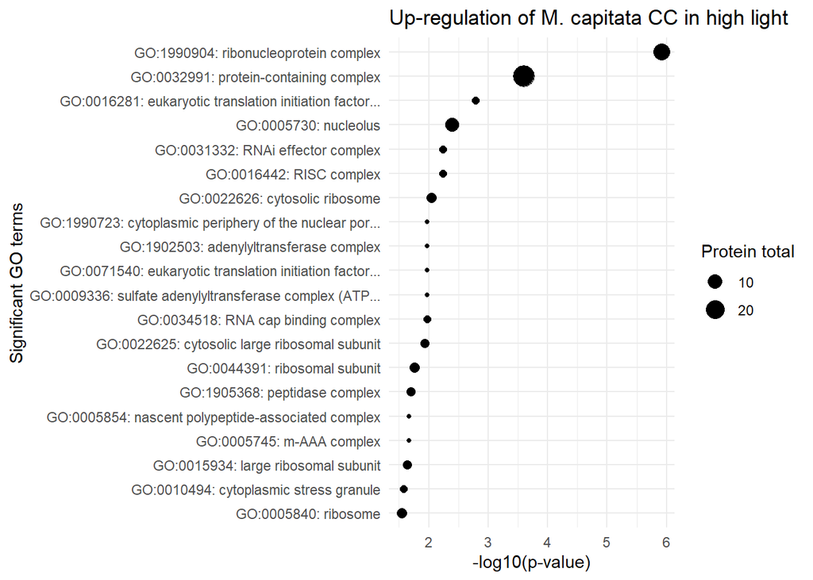

```r
GO_enrichment_plot
```

Ribonucleoprotein complex.

# Differences in the symbionts

EggNog.

```r
symbiont_egg <- read.csv("Galaxy24-[eggNOG_Mapper_on_Symb.C1_Gene_Models.PEP__annotations].TABULAR",sep="\t")
colnames(symbiont_egg)
```

```
##  [1] "Query"          "seed_ortholog"  "evalue"         "score"
##  [5] "eggNOG_OGs"     "max_annot_lvl"  "COG_category"   "Description"
##  [9] "Preferred_name" "GOs"            "EC"             "KEGG_ko"
## [13] "KEGG_Pathway"   "KEGG_Module"    "KEGG_Reaction"  "KEGG_rclass"
## [17] "BRITE"          "KEGG_TC"        "CAZy"           "BiGG_Reaction"
## [21] "PFAMs"
```

```r
dim(symbiont_egg)[1]
```

```
## [1] 22545
```

KEGG.

```r
symbiont_KEGG <- read.csv("Blast_Koala_Symb.C1_Gene_Models.PEP.txt",sep="\t")
colnames(symbiont_KEGG)
```

```
## [1] "Query" "KO"
```

```r
dim(symbiont_KEGG)[1]
```

```
## [1] 22791
```

Bind egg and KEGG together.

```r
symbiont_bio <- symbiont_KEGG %>%
  left_join(symbiont_egg,by="Query")
colnames(symbiont_bio)
```

```
##  [1] "Query"          "KO"             "seed_ortholog"  "evalue"
##  [5] "score"          "eggNOG_OGs"     "max_annot_lvl"  "COG_category"
##  [9] "Description"    "Preferred_name" "GOs"            "EC"
## [13] "KEGG_ko"        "KEGG_Pathway"   "KEGG_Module"    "KEGG_Reaction"
## [17] "KEGG_rclass"    "BRITE"          "KEGG_TC"        "CAZy"
## [21] "BiGG_Reaction"  "PFAMs"
```

```r
length(FASTA_symbiont)
```

```
## [1] 35913
```

```r
dim(symbiont_bio)[1]
```

```
## [1] 22791
```

UniProt information for different proteins.

```r
symbiont_uniprot <- read.csv("symbiont_different_names.txt",sep="\t")
colnames(symbiont_uniprot)
```

```
## [1] "name"          "Protein.Names" "Gene.Names"
```

```r
dim(symbiont_uniprot)[1]
```

```
## [1] 5
```

Add data to differential abundance data.

```r
symbiont_DAP <- prot_DAP %>%
  filter(Organism != "Montipora capitata") %>%
  left_join(symbiont_bio %>% dplyr::rename(name=Query),by="name") %>%
  left_join(symbiont_uniprot,by="name") %>%
  mutate(Given_name = ifelse(Preferred_name == "-" | is.na(Preferred_name),name,Preferred_name)) %>%
  group_by(Given_name) %>%
  mutate(dup_count = row_number()) %>%
  ungroup() %>%
  mutate(Given_name = ifelse(dup_count > 1, paste0(Given_name, " (", dup_count, ")"), Given_name)) %>%
  dplyr::select(-dup_count)
colnames(symbiont_DAP)
```

```
##  [1] "Organism"       "name"           "Protein.Group"  "log2FC"
##  [5] "AveExpr"        "t"              "P.Value"        "adj.P.Val"
##  [9] "B"              "Abundance"      "KO"             "seed_ortholog"
## [13] "evalue"         "score"          "eggNOG_OGs"     "max_annot_lvl"
## [17] "COG_category"   "Description"    "Preferred_name" "GOs"
## [21] "EC"             "KEGG_ko"        "KEGG_Pathway"   "KEGG_Module"
## [25] "KEGG_Reaction"  "KEGG_rclass"    "BRITE"          "KEGG_TC"
## [29] "CAZy"           "BiGG_Reaction"  "PFAMs"          "Protein.Names"
## [33] "Gene.Names"     "Given_name"
```

```r
dim(symbiont_DAP)[1]
```

```
## [1] 1747
```

Heatmap.

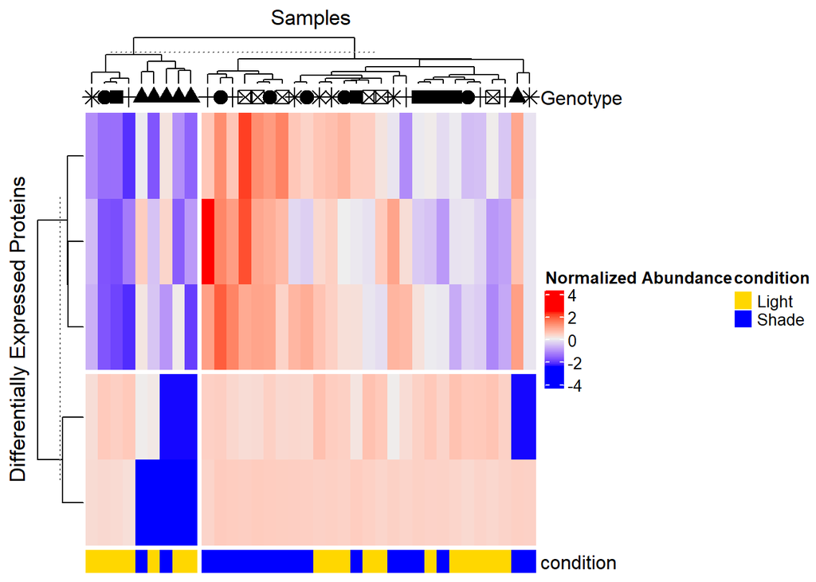

```r
Abundance_DAP <- prot_wide %>%
  filter(Organism != "Montipora capitata") %>%
  dplyr::select(-c(Organism,ID,Protein.Group,Genes)) %>%
  left_join(prot_DAP %>% dplyr::select(name,Abundance),by="name") %>%
  filter(Abundance != "no difference") %>%
  dplyr::select(-c(Abundance)) %>%
  column_to_rownames(var="name") %>%
  mutate_all(~replace(., is.na(.), 0)) %>%
  as.matrix()
# Z-score normalization for better visualization
Abundance_DAP_normalized <- t(scale(t(Abundance_DAP)))

# Create annotation data
column_annotations <- design[match(colnames(Abundance_DAP_normalized), design$Sample_ID), c("Genotype", "condition")]
genotype_symbols <- c("19" = 19, "60" = 17, "64" = 15, "64Y" = 3, "90" = 7, "P1R2" = 8)
ha_genotype <- columnAnnotation(
  Genotype = anno_simple(column_annotations$Genotype, pch = genotype_symbols[column_annotations$Genotype],
                         gp = gpar(col = "black", fill = NA,lty=0,fontsize=2))
)
condition_colors <- c("Light" = "gold", "Shade" = "blue")

# Create the heatmap annotation for condition
ha_condition <- columnAnnotation(
  condition = column_annotations$condition,
  col = list(condition = condition_colors)
)

heatmap_plot <- Heatmap(Abundance_DAP_normalized,
        name = "Expression",
        cluster_rows = TRUE,  # Cluster rows (proteins)
        cluster_columns = TRUE,  # Cluster columns (samples)
        show_row_names = FALSE, # Hide row names if too many
        show_column_names = FALSE,  # Show column names
        column_title = "Samples",
        row_title = "Differentially Expressed Proteins",
        heatmap_legend_param = list(title = "Normalized Abundance"),
        row_km = 2,
        column_km = 2,
        bottom_annotation = ha_condition,
        top_annotation = ha_genotype)
heatmap_plot
```

Volcano plot.

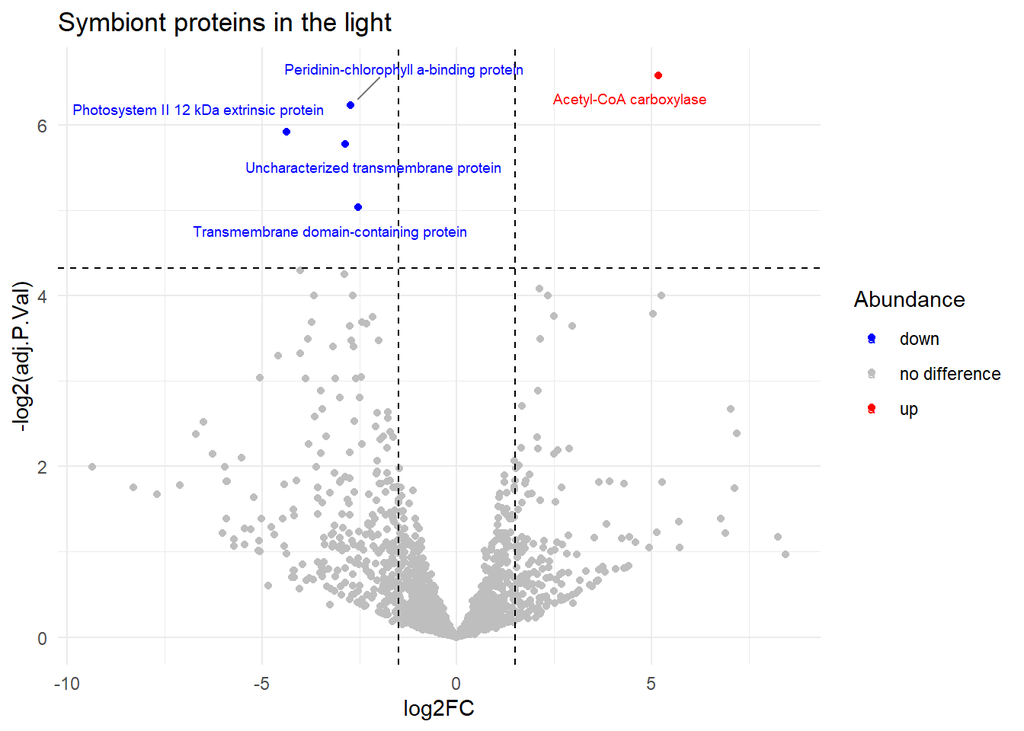

```r
volcano_plot <- ggplot(symbiont_DAP %>%
                         filter(!is.na(Abundance)),
                       aes(x = log2FC, y = -log2(adj.P.Val), color = Abundance)) +
  geom_point() +
  geom_hline(yintercept = -log2(0.05), linetype = "dashed", color = "black") +
  geom_vline(xintercept = c(-1.5, 1.5), linetype = "dashed", color = "black") +
  scale_color_manual(values = c("down" = "blue", "up" = "red", "no difference" = "grey")) +
  theme_minimal() +
  labs(title = "Symbiont proteins in the light") +
  geom_text_repel(aes(label = ifelse(Abundance != "no difference", Protein.Names, "")),
                  size = 2.5,
                  box.padding = 0.5,
                  point.padding = 0.5,
                  max.overlaps = Inf,
                  segment.color = "grey50")
volcano_plot
```

BRITE enrichment down-regulated proteins.

```r
# Background, proteins of interest and relevant term.
prot_rich_term <- symbiont_DAP %>%
  mutate(interest = Abundance == "down") %>%
  dplyr::rename(term = BRITE) %>%
  filter(!is.na(term)) %>%
  dplyr::select(name,adj.P.Val,log2FC,Abundance,interest,term)
# Terms associated with proteins.
term_df <- prot_rich_term %>%
  separate_rows(term, sep = ",")
# Term over-representation analysis.
term_enrich <- enricher(
  gene = prot_rich_term %>%
    filter(interest == TRUE) %>%
    dplyr::select(name) %>%
    unlist() %>%
    as.character(),
  TERM2GENE = term_df %>%
    dplyr::select(term,name),
  pAdjustMethod = "BH",
  qvalueCutoff = 0.01
)
term_enrich_result <- term_enrich@result
term_enrich
```

```
## #
## # over-representation test
## #
## #...@organism     UNKNOWN
## #...@ontology     UNKNOWN
## #...@gene     chr [1:2] "SymbC1.scaffold10535.1" "SymbC1.scaffold715.9"
## #...pvalues adjusted by 'BH' with cutoff <0.05
## #...0 enriched terms found
## #...Citation
##  T Wu, E Hu, S Xu, M Chen, P Guo, Z Dai, T Feng, L Zhou, W Tang, L Zhan, X Fu, S Liu, X Bo, and G Yu.
##  clusterProfiler 4.0: A universal enrichment tool for interpreting omics data.
##  The Innovation. 2021, 2(3):100141
```

# Photosynthesis

RUBISCO.

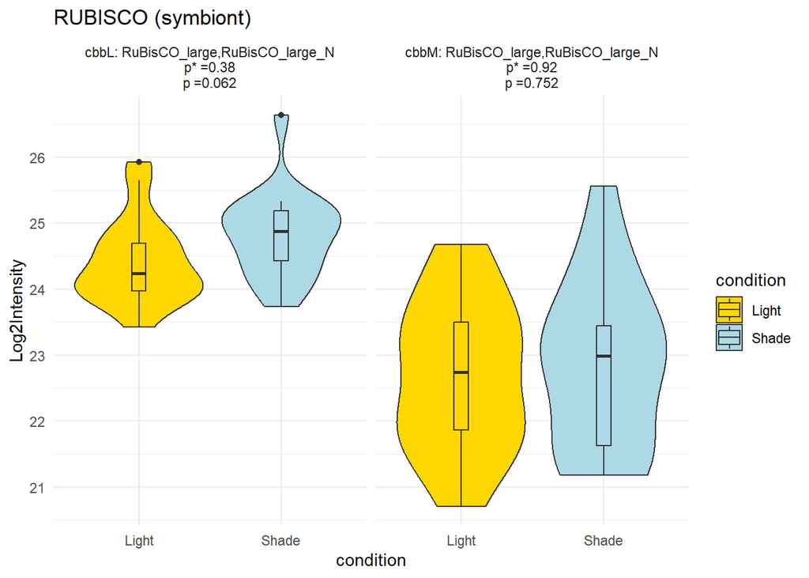

```r
symbiont_DAP %>%
  filter(grepl("cbb",Given_name)) %>%
  mutate(Given_name_with_p = paste(paste(Given_name,": ",str_trunc(PFAMs, width = 30, side = "right", ellipsis = "..."),sep=""),
                                   "\np* =",format(adj.P.Val, digits = 2),
                                   "\np =",format(P.Value, digits = 2),sep="")) %>%
  dplyr::select(name,Given_name_with_p) %>%
  left_join(prot_long %>% dplyr::select(name,Log2Intensity,condition,Genotype),by="name") %>%
  ggplot(aes(x=condition,y=Log2Intensity,fill=condition))+
  geom_violin() +
  geom_boxplot(width=0.1) +
  scale_fill_manual(values = c("Light" = "gold", "Shade" = "lightblue")) +
  facet_wrap(~Given_name_with_p) +
  theme_minimal() +
  labs(x="condition",
       title = "RUBISCO (symbiont)")
```

Photosynthesis proteins

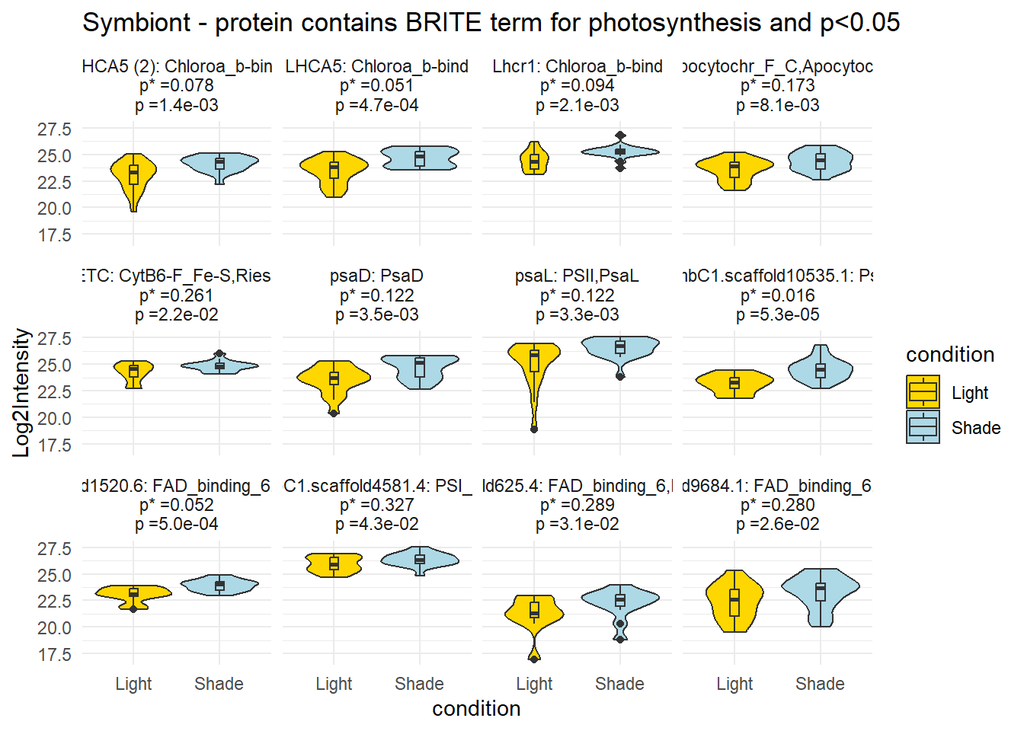

```r
symbiont_DAP %>%
  filter(grepl("ko00194",BRITE), P.Value < 0.05) %>%
  mutate(Given_name_with_p = paste(paste(Given_name,": ",str_trunc(PFAMs, width = 30, side = "right", ellipsis = "..."),sep=""),
                                   "\np* =",format(adj.P.Val, digits = 2),
                                   "\np =",format(P.Value, digits = 2),sep="")) %>%
  dplyr::select(name,Given_name_with_p) %>%
  left_join(prot_long %>% dplyr::select(name,Log2Intensity,condition,Genotype),by="name") %>%
  ggplot(aes(x=condition,y=Log2Intensity,fill=condition))+
  geom_violin() +
  geom_boxplot(width=0.1) +
  scale_fill_manual(values = c("Light" = "gold", "Shade" = "lightblue")) +
  facet_wrap(~Given_name_with_p) +
  theme_minimal() +
  labs(x="condition",
       title = "Symbiont - protein contains BRITE term for photosynthesis and p<0.05")
```

# Reactive oxygen species and protein degradation

M. capitata SOD and CAT.

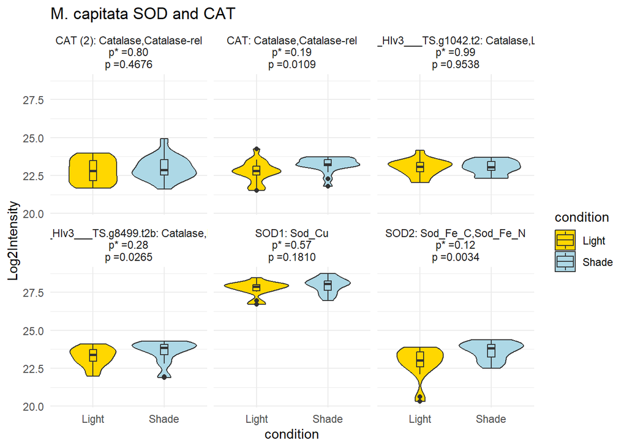

```r
SOD_plot <- Mcap_DAP %>%
  filter(grepl("SOD",Given_name) |
           grepl("Catalase",PFAMs) | Given_name == "CAT" | Given_name == "CAT (2)") %>%
  mutate(Given_name_with_p = paste(paste(Given_name,": ",str_trunc(PFAMs, width = 30, side = "right", ellipsis = "..."),sep=""),
                                   "\np* =",format(adj.P.Val, digits = 2),
                                   "\np =",format(P.Value, digits = 2),sep="")) %>%
  dplyr::select(name,Given_name_with_p) %>%
  left_join(prot_long %>% dplyr::select(name,Log2Intensity,condition,Genotype),by="name") %>%
  ggplot(aes(x=condition,y=Log2Intensity,fill=condition))+
  geom_violin() +
  geom_boxplot(width=0.1) +
  scale_fill_manual(values = c("Light" = "gold", "Shade" = "lightblue")) +
  facet_wrap(~Given_name_with_p) +
  theme_minimal() +
  labs(x="condition",
       title = "M. capitata SOD and CAT")
SOD_plot
```

Symbiont SOD.

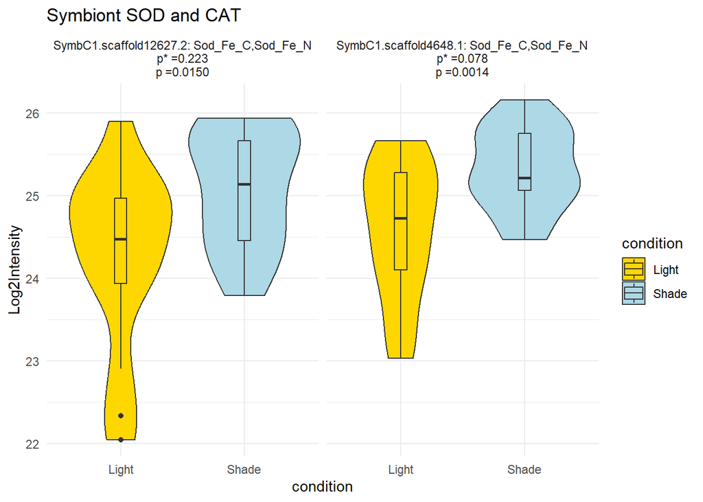

```r
symbiont_DAP %>%
  filter(grepl("Sod",PFAMs) | grepl("Catalase",PFAMs),P.Value<0.05) %>%
  mutate(Given_name_with_p = paste(paste(Given_name,": ",str_trunc(PFAMs, width = 30, side = "right", ellipsis = "..."),sep=""),
                                   "\np* =",format(adj.P.Val, digits = 2),
                                   "\np =",format(P.Value, digits = 2),sep="")) %>%
  dplyr::select(name,Given_name_with_p) %>%
  left_join(prot_long %>% dplyr::select(name,Log2Intensity,condition,Genotype),by="name") %>%
  ggplot(aes(x=condition,y=Log2Intensity,fill=condition))+
  geom_violin() +
  geom_boxplot(width=0.1) +
  scale_fill_manual(values = c("Light" = "gold", "Shade" = "lightblue")) +
  facet_wrap(~Given_name_with_p) +
  theme_minimal() +
  labs(x="condition",
       title = "Symbiont SOD and CAT")
```

Protein degradation

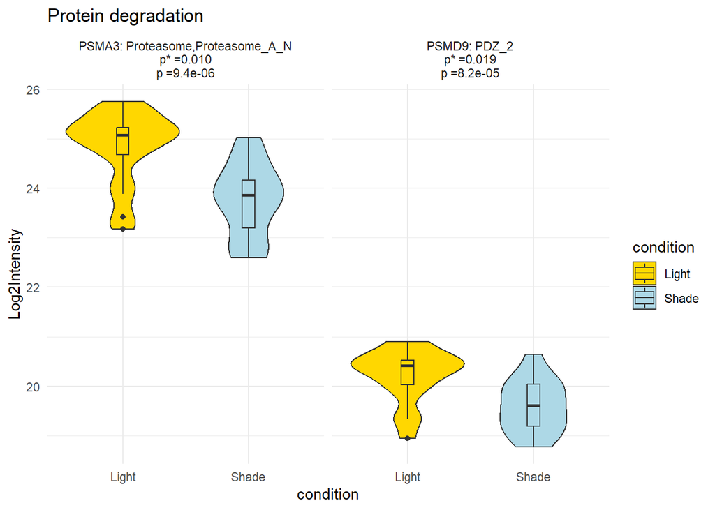

```r
Mcap_DAP %>%
  filter(Given_name == "PSMA3" | Given_name == "PSMD9") %>%
  mutate(Given_name_with_p = paste(paste(Given_name,": ",str_trunc(PFAMs, width = 30, side = "right", ellipsis = "..."),sep=""),
                                   "\np* =",format(adj.P.Val, digits = 2),
                                   "\np =",format(P.Value, digits = 2),sep="")) %>%
  dplyr::select(name,Given_name_with_p) %>%
  left_join(prot_long %>% dplyr::select(name,Log2Intensity,condition,Genotype),by="name") %>%
  ggplot(aes(x=condition,y=Log2Intensity,fill=condition))+
  geom_violin() +
  geom_boxplot(width=0.1) +
  scale_fill_manual(values = c("Light" = "gold", "Shade" = "lightblue")) +
  facet_wrap(~Given_name_with_p) +
  theme_minimal() +
  labs(x="condition",
       title = "Protein degradation")
```